# PRECIS-2 Scores in PragMeta: Human Consensus vs LMM (Claude 2) - 2nd run

### Score comparisons of 56 publications

| Ref. | Author & Year | weighted κ | agreement | pooled weighted κ | pooled agreement |
| --- | --- | --- | --- | --- | --- |
| 648 | CORONIS Collaborative Group (2013) | 0.064935064935065 | 0.222222222222222 | 0.234042553191489 | 0.555555555555556 |
| 650 | van Dijk-de Vries. A, (2015) | 0.00917431192660556 | 0.333333333333333 | -0.161290322580645 | 0.555555555555556 |
| 651 | Price. D, (2011) | -0.125 | 0.333333333333333 | 0 | 0.888888888888889 |
| 655 | Galdiz, J. B. (2020) | -0.35 | 0.222222222222222 | -0.35 | 0.333333333333333 |
| 657 | Arntzen E. (2019) | 0.5 | 0.555555555555556 | -0.125 | 0.777777777777778 |
| 662 | Bogosian A. (2015) | 0.41304347826087 | 0.333333333333333 | 0.357142857142857 | 0.555555555555556 |
| 663 | Callesen J. (2020) | 0.23728813559322 | 0.777777777777778 | 0 | 0.888888888888889 |
| 664 | Carter A. (2014) | -0.178571428571429 | 0.111111111111111 | -0.285714285714286 | 0.333333333333333 |
| 665 | Cooper C. (2011) | 0.172972972972973 | 0.111111111111111 | 0 | 0.222222222222222 |
| 666 | Cutter G. (2019) | 0.694915254237288 | 0.444444444444444 | 0.678571428571429 | 0.666666666666667 |

[output cut: 46 more lines]

### Score heatmaps (unpooled / pooled)

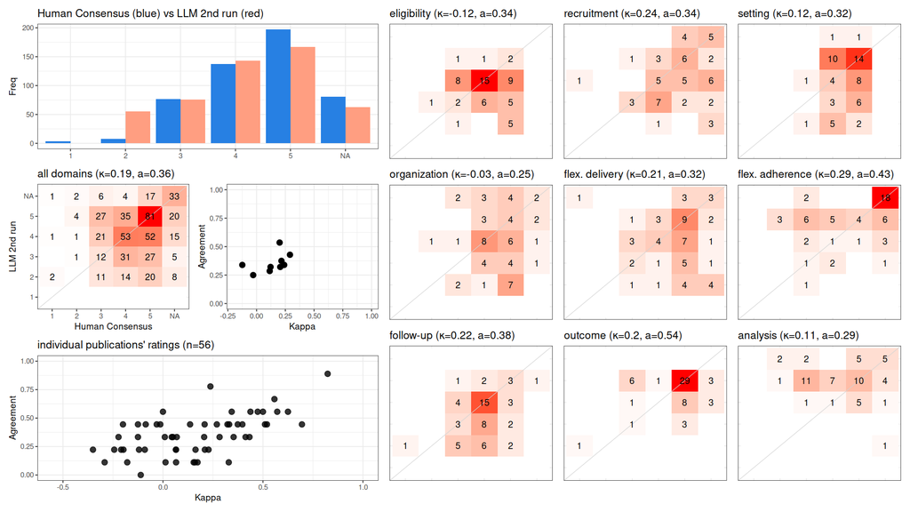

### Individual results

#### CORONIS Collaborative Group (2013): CORONIS Collaborative Group (2013)

PRECIS-2

|  | eligibility | recruitment | setting | organization | flex. delivery | flex. adherence | follow-up | outcome | analysis |
| --- | --- | --- | --- | --- | --- | --- | --- | --- | --- |
| Human Consensus | 4 | NA | 5 | 5 | 3 | NA | 5 | 3 | 3 |
| LLM 2nd run | 4 | NA | 4 | 4 | 4 | 4 | 4 | 5 | 5 |

LLM response

```
 Here are the PRECIS-2 scores for the trial based on the full text in "648.pdf":

Eligibility criteria

Relevant quotes:
- "Pregnant women were eligible if they were to undergo delivery by lower segment caesarean section through a planned transverse abdominal incision, irrespective of fever in labour, gestational age, or multiple pregnancies."
- "Women were not eligible if there was a clear indication for a particular surgical technique or material to be used that prevented any of the allocated interventions being used, if they had more than one previous caesarean section, or if they had already been recruited into the trial."

Reasoning: The eligibility criteria are quite broad, including women undergoing both elective and emergency cesarean section, at any gestational age or with multiple pregnancies. The only exclusions are if there is a medical reason requiring a specific technique, more than one previous cesarean, or …

Score: [4] Rather pragmatic

Recruitment:

Relevant quotes:
- No details provided on recruitment process.

Reasoning: There is no information provided in the text about how participants were recruited, such as whether any special efforts beyond usual practice were made. In the absence of these details, I cannot assess this domain.

Score: [NA]

Setting:

Relevant quotes:
- "CORONIS was undertaken at 19 sites in Argentina, Chile, Ghana, India, Kenya, Pakistan, and Sudan."

Reasoning: The trial was undertaken across multiple sites in 7 countries. This enhances the generalizability of the findings. No details are provided on whether the sites were specialist centers. In the absence of mention of restrictive site selection, the setting seems pragmatic.

Score: [4] Rather pragmatic

Organization:

Relevant quotes:
- "Each regional coordinator (one per country, except India, which was split into two regions) started and documented a training programme that ensured that surgeons operating within the trial were familiar with the techniques being compared before participating."

Reasoning: Some training was provided to ensure surgeons were familiar with the techniques, but no other changes to resources, staffing or expertise were mentioned. The training aimed to ensure proper delivery of the interventions being compared, rather than optimizing care beyond normal practice. O…

Score: [4] Rather pragmatic

Flexibility (delivery):
```

[output cut: 29 more lines]

```
Relevant quotes:
- "The primary outcome was a composite of death, maternal infectious morbidity, further operative procedures, or blood transfusion (>1 unit of whole blood or packed cells) up to the 6-week follow-up visit."

Reasoning: The composite primary outcome includes clinically meaningful events like death, infection, need for more procedures and blood transfusion. These would all be important outcomes from the perspective of patients as well.

Score: [5] Very pragmatic

Primary analysis:

Relevant quotes:
- "Women were analysed in the groups into which they were allocated."

Reasoning: Women were analyzed by original group allocation, implying an intention-to-treat approach which is pragmatic.

Score: [5] Very pragmatic
```

#### [van Dijk-de Vries. A, (2015)](https://doi.org/10.1136/bmjopen-2014-007014): van Dijk-de Vries. A, (2015)

PRECIS-2

|  | eligibility | recruitment | setting | organization | flex. delivery | flex. adherence | follow-up | outcome | analysis |
| --- | --- | --- | --- | --- | --- | --- | --- | --- | --- |
| Human Consensus | 3 | 4 | 5 | 4 | 5 | NA | 4 | 5 | 3 |
| LLM 2nd run | 4 | 3 | 4 | 4 | 4 | 5 | 4 | 5 | 5 |

LLM response

```
 Here are the PRECIS-2 scores for the 9 domains based on the attached clinical trial publication (van Dijk-de Vries et al., 2015):

1. Eligibility criteria

Relevant quotes:

"Patients with a clinically established diagnosis of type 2 diabetes mellitus were sent a letter by their GPs to introduce the SMS project. The enclosed self-administered questionnaire consisted of the screening instruments that intervention PNs would also apply for SMS in their routine practice. It…

"From all 1805 patients who participated in the screening, 357 (20%) met the detection criteria and were invited to take part in the trial."

Reasoning: The eligibility criteria appear to closely match what would be used in routine practice - patients with an established diagnosis of type 2 diabetes were screened using simple tools (DFT and DS) that the practice nurses would use in routine care. The 20% of screened patients who met the de…

Score: [4]

2. Recruitment

Relevant quotes:

"Patients with a clinically established diagnosis of type 2 diabetes mellitus were sent a letter by their GPs to introduce the SMS project."

"The screening questionnaires were sent by GPs, we could not compare responders with non-responders with regard to demographic characteristics."

Reasoning: Patients were recruited through screening questionnaires sent by their regular GPs, similar to how they would be identified in routine practice. No other recruitment methods like media advertising were used. However, there is no data provided on how representative the responders were.

Score: [3]

3. Setting

Relevant quotes:

"The study was conducted between November 2011 and February 2013 and was registered in a Dutch public trial registry [NTR2764]. The study involved practice nurses (n=40) providing care to approximately 4000 patients with diabetes."

"From the 77 family practices that were approached between April and June 2011, 40 agreed to participate."

Reasoning: The trial was conducted across multiple (40) family practices in the Netherlands, a setting very similar to routine diabetes care. No specialist centers were used.

Score: [4]

4. Organization

```

[output cut: 44 more lines]

```
"The primary outcome measure was a dichotomised score on a Visual Analogue Scale that measured the perceived effect of diabetes on daily functioning."

Reasoning: The primary outcome directly measures the patient's perceived functioning and impact of diabetes in daily life, which is highly relevant.

Score: [5]

9. Primary analysis

Relevant quote:

"Analyses were performed on an intention-to-treat basis."

Reasoning: An intention-to-treat analysis was used, implying all randomized patients were included.

Score: [5]
```

#### [Price. D, (2011)](https://doi.org/10.1056/NEJMoa1010846): Price. D, (2011)

PRECIS-2

|  | eligibility | recruitment | setting | organization | flex. delivery | flex. adherence | follow-up | outcome | analysis |
| --- | --- | --- | --- | --- | --- | --- | --- | --- | --- |
| Human Consensus | 5 | 5 | 5 | NA | 4 | 4 | 4 | 5 | 4 |
| LLM 2nd run | 4 | 5 | 5 | 5 | 5 | 5 | 5 | 5 | 5 |

LLM response

```
 Here are the PRECIS-2 domain scores and explanations for the trial described in the publication "651.pdf":

Eligibility criteria

Quotes:
"Eligible primary care patients 12 to 80 years of age had impaired asthma-related quality of life (Mini Asthma Quality of Life Questionnaire [MiniAQLQ] score ≤6) or inadequate asthma control (Asthma Control Questionnaire [ACQ] score ≥1)."

"Other eligibility criteria for both trials included, at screening, a peak expiratory flow (PEF) greater than 50% of the predicted value after an inhaled beta2-agonist had been withheld for 4 hours or longer and, at the baseline visit, evidence of impaired asthma-related quality of life (a score ≤6 …

"Main exclusion criteria were prior treatment within 12 weeks with an inhaled glucocorticoid or LTRA (in the first-line controller therapy trial) or LTRA or LABA (in the add-on therapy trial)."

Explanation: The eligibility criteria are fairly broad, including adult primary care patients with asthma who have impaired quality of life or inadequate symptom control based on validated questionnaires. The main exclusions are prior treatments with drugs in the trial classes within 12 weeks. Overa…

Score: [4] Rather pragmatic

Recruitment

Quote: "Patients who met the eligibility criteria completed a validated asthma-symptom diary for 2 weeks before the baseline visit for an assessment of PEF variability and to record current symptoms."

Explanation: Patients were recruited when they presented for asthma care in their primary care practices. No special efforts like advertising or incentives were mentioned. This matches usual care recruitment.

Score: [5] Very pragmatic

Setting

Quote: "The two trials, which were conducted in parallel, and the study procedures were similar in the two trials. Both trials were conducted in accordance with the protocol. The trials were conducted at 53 primary care practices in the United Kingdom."

Explanation: The trial was conducted in multiple primary care practices, which is the typical setting where the treatments would be used in usual care.

Score: [5] Very pragmatic

Organisation

Quotes:
"Practice staffs were asked to provide each patient with a written individualized asthma-action plan."

"For each of the assigned treatments, choices of individual drugs and devices were made according to normal clinical practice and British asthma guidelines."

Explanation: The trial appears to use the existing staff and resources at the primary care practices to deliver the interventions, matching usual care. No additional training, staffing, or resources were mentioned.

```

[output cut: 29 more lines]

```
"The primary outcome measure was the MiniAQLQ score."

"Eligible primary care patients 12 to 80 years of age had impaired asthma-related quality of life (Mini Asthma Quality of Life Questionnaire [MiniAQLQ] score ≤6) or inadequate asthma control (Asthma Control Questionnaire [ACQ] score ≥1)."

Explanation: The MiniAQLQ measures asthma quality of life, which is a key outcome for patients. Impaired quality of life was part of the eligibility criteria, indicating its importance.

Score: [5] Very pragmatic

Primary analysis

Quote: "The primary effectiveness analysis was an intention-to-treat analysis of the MiniAQLQ score at 2 months (the primary time point) and at 2 years."

Explanation: An intention-to-treat approach was used as the primary analysis. This pragmatically includes all randomized patients.

Score: [5] Very pragmatic
```

#### [Galdiz, J. B. (2020)](https://doi.org/10.1016/j.arbres.2020.03.034): Galdiz, J. B. (2020)

PRECIS-2

|  | eligibility | recruitment | setting | organization | flex. delivery | flex. adherence | follow-up | outcome | analysis |
| --- | --- | --- | --- | --- | --- | --- | --- | --- | --- |
| Human Consensus | 3 | NA | 5 | 4 | 5 | 3 | 4 | 3 | 3 |
| LLM 2nd run | 3 | 4 | 4 | NA | 2 | 3 | 2 | 4 | 5 |

LLM response

```
 Here are the PRECIS-2 scores and rationale for the clinical trial described in the paper "Telerehabilitation Programme as a Maintenance Strategy for COPD Patients: A 12-Month Randomized Clinical Trial":

Eligibility criteria:

Relevant quotes:
- "Patient selection criteria were having a diagnosis of moderate-to-severe COPD (a Body mass index, Airflow obstruction, dyspnoea and Exercise capacity [BODE] index score of 3–7) according to international guidelines and having been clinically stable for the previous 4 weeks."
- "Patients gave written informed consent."

Rationale: The eligibility criteria are moderately pragmatic - patients have confirmed COPD diagnosis and a specified severity based on BODE index. They must also be clinically stable for 4 weeks prior. While a more pragmatic trial may include patients with only a clinical suspicion of COPD, the cri…

Score: [3]

Recruitment:

Relevant quotes:
- "Recruited patients (recruitment visit, −1) attended an initial 8-week outpatient-based PR programme conducted in each hospital rehabilitation department."

Rationale: Patients were recruited when they attended the initial 8-week pulmonary rehabilitation program at participating hospitals. This matches usual care since patients would normally be referred for PR by their physician. No additional recruitment efforts are mentioned.

Score: [4]

Setting:

Relevant quotes:
- "This was a multicentre open-label pragmatic parallel-group randomized clinical trial involving 13 hospitals."
- "The study was carried out in accordance with the principles of the Declaration of Helsinki and started after receiving authorization from the Spanish Agency for Medicines and Health Products and the approval of the Basque Country Ethics Committee, as well as the local Ethics Committee and Directo…

Rationale: The trial was conducted across 13 hospitals in Spain. Multicenter trials allow for a diversity of settings and increase generalizability. Conducting the trial in routine hospital settings where COPD patients would receive care makes it more pragmatic.

Score: [4]

Organization:

Relevant quotes:
- No quotes specifically about organization.

Rationale: No details are provided about organization of care delivery or additional resources, staffing, training etc. It appears the hospitals provided care as usual during the trial.

Score: [NA]

```

[output cut: 32 more lines]

```
- "Exercise tolerance (the ability to sustain exercise) was assessed using distance covered in the 6MWT."

Rationale: The 6-minute walk test is a standard measure of exercise capacity and endurance. It provides information that is clinically meaningful for COPD patients.

Score: [4]

Primary analysis:

Relevant quotes:
- "All patients were analyzed in the group to which they were randomized."
- "ANCOVA of between-group differences at 12-month visit."

Rationale: An intention-to-treat approach was used - patients were analyzed based on original group assignment. The primary analysis was ANCOVA at 12 months.

Score: [5]
```

#### [Arntzen E. (2019)](https://doi.org/10.1093/ptj/pzz017): Arntzen E. (2019)

PRECIS-2

|  | eligibility | recruitment | setting | organization | flex. delivery | flex. adherence | follow-up | outcome | analysis |
| --- | --- | --- | --- | --- | --- | --- | --- | --- | --- |
| Human Consensus | 3 | 4 | 5 | 4 | 5 | 4 | 4 | 5 | 5 |
| LLM 2nd run | 4 | 3 | 4 | 4 | 5 | 5 | 4 | 5 | 5 |

LLM response

```
 Here are the PRECIS-2 scores for the trial based on the full text in "657.pdf":

Eligibility criteria

Relevant quotes:

"Eighty people with Expanded Disability Status scores of 1 to 6.5 participated in this trial."

"Inclusion criteria were as follows: (1) diagnosed with MS in accordance with the McDonald criteria; (2) registered at the MS outpatient clinic; (3) living in 1 of 6 selected municipalities; (4) aged 18 years or older; (5) capable of providing signed written informed consent; and (6) EDSS score betw…

"Exclusion criteria were as follows: (1) pregnancy at time of examination; (2) exacerbation in the previous 2 weeks before enrollment; and (3) other acute conditions compromising balance."

Reasoning: The inclusion criteria reflect the intended population - ambulant individuals with MS across a range of disability levels, consistent with those who would receive this intervention in usual care. The exclusion criteria are reasonable and do not overly restrict the population beyond what w…

Score: [4]

Recruitment

Relevant quotes:

"In August 2015, 1 of the MS nurses at the Department of Neurology, Nordland Hospital Trust in Bodø, Norway, sent out invitation letters with a consent form to 160 persons with MS who were registered at the MS outpatient clinic, had EDSS scores of 0 to 7, and lived in 1 of the 6 municipalities inclu…

"To ensure maximum patient enrollment, 1 reminder letter was sent out to the nonresponders."

Reasoning: Participants were identified from an MS clinic registry and invited by letter, which requires some additional effort beyond routine appointments but is still reasonably pragmatic. Only one reminder letter was sent to non-responders.

Score: [3]

Setting

Relevant quotes:

"Assessments at all time points took place at a Norwegian hospital."

"The GroupCoreDIST intervention was conducted by 6 physical therapists in 6 municipalities in Norway."

Reasoning: The setting for assessments was a hospital, which is likely routine care for this population. The intervention itself was delivered in multiple municipalities, reflecting the typical care setting.

Score: [4]

```

[output cut: 48 more lines]

```
Reasoning: The outcomes measure clinically meaningful aspects of balance and trunk control that are relevant to participants.

Score: [5]

Primary analysis

Relevant quotes:

"Repeated-measures mixed models were used for statistical analysis."

"The intention-to-treat analysis using repeated-measures mixed models in IBM SPSS Version 24."

Reasoning: Analysis was based on intention-to-treat with all available data.

Score: [5]
```

#### [Bogosian A. (2015)](https://doi.org/10.1177/1352458515576261): Bogosian A. (2015)

PRECIS-2

|  | eligibility | recruitment | setting | organization | flex. delivery | flex. adherence | follow-up | outcome | analysis |
| --- | --- | --- | --- | --- | --- | --- | --- | --- | --- |
| Human Consensus | 5 | 4 | 5 | 4 | 3 | NA | 3 | 5 | 5 |
| LLM 2nd run | 3 | 3 | 3 | 3 | 3 | NA | 3 | 4 | 4 |

LLM response

```
 Here are the PRECIS-2 scores for the trial based on the full text publication:

Eligibility criteria

Quotes:
"Inclusion criteria were diagnosis of PPMS or SPMS, Internet access and some level of distress determined by a score of 3 or greater on the General Health Questionnaire (GHQ-12)."

"Exclusion criteria were severe cognitive impairment, as determined by a score of 20 or smaller on the Telephone Interview for Cognitive Status-Modified (TICS-M) and high suicide risk, as assessed by a score of 20 or greater on the Clinical Outcome of Routine Evaluation (CORE-10)."

Reasoning: The eligibility criteria are fairly broad, including patients with PPMS or SPMS which represent the target population. However, patients were screened for distress and excluded if they had severe cognitive impairment or high suicide risk. The additional screening beyond just diagnosis may…

Score: [3]

Recruitment:

Quote: "We recruited potential participants through adverts on the MS Society website and from National Health Service (NHS) MS centres across the UK."

Reasoning: Participants were recruited through the MS Society website and NHS centers, which are reasonable sources for the target population. No extraordinary efforts like media campaigns or incentives were mentioned. Overall, recruitment seems moderately pragmatic.

Score: [3]

Setting:

Quote: "We administered the screening questionnaires via telephone."

Reasoning: The setting is not described in detail. Administration of screening questionnaires by telephone suggests this was likely done remotely rather than in a clinic setting. This may limit generalizability to some extent.

Score: [3]

Organisation:

Quotes:
"We delivered the programme in eight hour-long sessions over an eight-week period via Skype video conferences."

"AB, a health psychologist, facilitated the courses. AB was supervised by PC, a clinical psychologist and expert mindfulness practitioner."

Reasoning: The intervention was delivered via Skype, which is likely more feasible and accessible than requiring in-person visits. A health psychologist facilitated the courses with supervision from an expert, suggesting reasonably typical staffing. Overall, organization seems moderately pragmatic.

Score: [3]

```

[output cut: 22 more lines]

```
Primary outcome:

Quote: "The GHQ is designed to measure general levels of distress. The GHQ is uncontaminated by the experience of MS-related somatic symptoms and is the most treatment-responsive measure of psychological distress in MS."

Reasoning: The primary outcome was distress measured by GHQ, which seems clinically relevant and important to patients.

Score: [4]

Primary analysis:

Quote: "Outcome analysis was conducted using Stata 12.1. To compare group demographic and clinical characteristics at baseline, we used a binomial test for equal proportions between groups for categorical variables and an independent t-test for equal means between groups for continuous variables. We…

Reasoning: Analysis was done on an intention-to-treat basis, which supports a pragmatic approach.

Score: [4]
```

#### [Callesen J. (2020)](https://doi.org/10.1177/1352458519865740): Callesen J. (2020)

PRECIS-2

|  | eligibility | recruitment | setting | organization | flex. delivery | flex. adherence | follow-up | outcome | analysis |
| --- | --- | --- | --- | --- | --- | --- | --- | --- | --- |
| Human Consensus | 4 | 4 | 5 | 5 | 5 | 5 | 4 | 5 | 3 |
| LLM 2nd run | 4 | 4 | 5 | 4 | 5 | 5 | 4 | 5 | 5 |

LLM response

```
 Here are the PRECIS-2 scores and explanations for the trial described in "663.pdf":

Eligibility criteria

Quotes:
- "Patients ≥ 3 with acute respiratory tract infections. Exclusions not common cold but severe respiratory tract infections, peptic ulcer and asthma. But even asthma patients who were not sensitive to ibuprofen or aspirin eligible. Pregnant or breast feeding women are discouraged from taking ibuprof…

Reasoning: The eligibility criteria are fairly broad, including patients with acute respiratory infections visiting primary care which is a typical patient population. Some exclusions like pregnant women are for safety reasons. Overall fairly pragmatic.

Score: [4]

Recruitment

Quotes:
- "Patients presenting to GP or nurse in primary care with respiratory tract infections as diagnosed by health professional. Easy to recruit to but time pressures in busy winter clinics prevented recruitment and meant non-recruitments logs poorly completed."

Reasoning: Patients were recruited during regular primary care visits, a very pragmatic approach. Some issues with recruitment due to time pressures indicates it was not ideal.

Score: [4]

Setting

Quotes:
- "Identical setting to usual care setting - primary care, where patients usually go for advice and treatment of the common cold in the UK."
- "Multi-centre: 25 practices in UK."

Reasoning: The setting of primary care clinics is identical to the usual care setting. Being multi-center also increases pragmatism.

Score: [5]

Organization

Quotes:
- "Information sheets given out to participants. This is not usual practice, would it be if trial had shown this helped? Need more staff for follow up of trial participants to get diary results so more extensive data collection than usual. Otherwise no difference in provider expertise and organisati…

Reasoning: Organization is fairly similar to usual care except for some additional information sheets and staff for follow-up. Still fairly pragmatic but some deviations.

Score: [4]

Flexibility (delivery)
```

[output cut: 30 more lines]

```
Quotes:
- "Very relevant to participants - Mean symptom severity on days 2-4. Symptoms 0 (no problem) to 6 (as bad as they can be 7 in abstract). Completed in diary at end of day – children with parents or participants."

Reasoning: Symptom severity is a very relevant primary outcome for participants with respiratory infections.

Score: [5]

Primary analysis

Quotes:
- "ITT no matter whether compliance."

Reasoning: Intention-to-treat analysis is a pragmatic approach.

Score: [5]
```

#### [Carter A. (2014)](https://doi.org/10.1177/1352458513519354): Carter A. (2014)

PRECIS-2

|  | eligibility | recruitment | setting | organization | flex. delivery | flex. adherence | follow-up | outcome | analysis |
| --- | --- | --- | --- | --- | --- | --- | --- | --- | --- |
| Human Consensus | 3 | 4 | 4 | 5 | 5 | 3 | 4 | 5 | 4 |
| LLM 2nd run | 4 | 3 | 2 | 2 | 4 | 5 | 3 | 5 | 5 |

LLM response

```
 Here are the PRECIS-2 domain scores and explanations for the trial described in the paper "Pragmatic intervention for increasing self-directed exercise behaviour and improving important health outcomes in people with multiple sclerosis: a randomised controlled trial" (664.pdf):

Eligibility criteria

Relevant quotes:
- "The inclusion criteria for the trial were clinical diagnosis of MS, as defined by the modified McDonald criteria, with an Expanded Disability Status Scale (EDSS) score of 1.0-6.5, and able to walk a 10-metre distance; aged 18-65 years; clinically stable for at least four weeks prior to entering t…
- "Exclusion criteria were comorbid conditions impairing the ability to be physically active three times per week; unwilling to be randomised; living more than 20 miles from the trial centre; already engaged in structured exercise or brisk walking ≥3 times per week for ≥30 minutes per session for at…

Reasoning: The inclusion criteria select participants typical of those who would receive exercise interventions in usual care. The exclusion criteria remove those unable to participate safely or adhere to the intervention. Overall, the criteria seem intended to enhance applicability to the target po…

Score: [4]

Recruitment

Relevant quotes:
- "PwMS were recruited via the Sheffield MS Clinic and flyers/community adverts displayed at the local South Yorkshire MS Society branches."

Reasoning: Participants were recruited through a clinic and community adverts, which requires some additional effort beyond routine appointments but is still moderately pragmatic. This approach would reach the target population.

Score: [3]

Setting

Relevant quotes:
- "Supervised exercise sessions involved up to three participants and lasted for approximately one hour."
- "Studies show that aerobic exercise, resistance exercise and combined programmes bring health benefits to PwMS."
- "The prescribed strength training was based on individual functional needs, as assessed by the trial physiotherapist (NS)."

Reasoning: The supervised exercise sessions took place at a university exercise research facility with input from physiotherapists. This specialized setting differs from the typical real-world setting where most patients receive exercise interventions.

Score: [2]

Organization

Relevant quotes:
- "An exercise physiologist supervised the delivery of the intervention but with physiotherapist input during the early stages of the programme."
- "Strength training was undertaken by 48 of 60 participants in the intervention group and typically involved two to six different resistance exercises (e.g. wall press-ups, arm-curls, leg abduction, wall squats and/or regular squats, knee extensions, calf raises, sit-to-stand) each session."

Reasoning: The intervention required supervision by an exercise physiologist and physiotherapist input, exceeding the expertise and resources commonly available. The strength training component was individualized based on physiotherapist assessment. This level of specialized staffing and individual …

```

[output cut: 33 more lines]

```
Relevant quotes:
- "The primary outcome was self-reported exercise behaviour at three months using the Godin Leisure Time Exercise Questionnaire (GLTEQ)."

Reasoning: The primary outcome of self-reported exercise behavior is directly relevant to participants and assesses a patient-centered goal of the intervention.

Score: [5]

Primary analysis

Relevant quote:
- "All analyses were by intention to treat, whereby participants were analysed in the arm to which they were randomised irrespective of whether they complied with the intervention."

Reasoning: The analysis followed an intention-to-treat approach, consistent with a pragmatic attitude.

Score: [5]
```

#### [Cooper C. (2011)](https://doi.org/10.1186/1745-6215-12-259): Cooper C. (2011)

PRECIS-2

|  | eligibility | recruitment | setting | organization | flex. delivery | flex. adherence | follow-up | outcome | analysis |
| --- | --- | --- | --- | --- | --- | --- | --- | --- | --- |
| Human Consensus | 4 | 4 | 5 | 5 | 5 | 4 | 4 | 5 | 4 |
| LLM 2nd run | 3 | 3 | 4 | NA | NA | 3 | 3 | 3 | 4 |

LLM response

```
 Here are the PRECIS-2 domain scores and justifications based on the trial publication:

Eligibility criteria:

Relevant quotes:
- "Inclusion criteria were: age of 18 years or above; BDI score of at least 14 on two consecutive occasions and no treatment from psychologist, psychotherapist or psychiatrist within the last three months."
- "Exclusion criteria were: poor English language skills or cognitive function (score of less than 24 on Mini Mental State Examination); BDI score of at least 29 on two consecutive occasions; active suicidal ideas; current or life-time diagnosis of psychosis, organic mental disorder or substance dep…

Reasoning: The inclusion criteria are reasonably broad, including adults with MS and BDI score ≥14. However, some exclusions like poor English, cognitive issues, psychosis, etc. reduce generalizability. The BDI cutoffs also exclude those with milder or more severe depression. Overall, moderately pra…

Score: [3]

Recruitment:

Relevant quotes:
- "Invitations were made between October 2008 and July 2009: face-to-face by consultants in the Sheffield Teaching Hospitals NHS Foundation Trust MS clinic (n = 288); by the Sheffield MS nurses visiting patients (n = 4); and, using ink-signed personalised letters mailed out from a neuropsychologist …

Reasoning: Recruitment was done through MS clinics and mailings to MS patients at two sites. This seems moderately pragmatic as it recruits through usual appointments and registries, but requires some additional effort beyond routine care.

Score: [3]

Setting:

Relevant quotes:
- "We reached our recruitment target on 30 July 2009 (in 281 days) after adding a second centre (The Walton Centre NHS Foundation Trust, Liverpool)."

Reasoning: The trial was conducted at two specialized MS centers. This limits generalizability somewhat but is reasonably pragmatic.

Score: [4]

Organization:

Relevant quotes:
- No clear information provided on resources, staffing, training, etc. for delivering the intervention.

Reasoning: The publication does not contain enough details to assess this domain.

Score: [NA]

Flexibility (delivery):
```

[output cut: 30 more lines]

```
Relevant quotes:
- "The primary clinical endpoint was the mean change in self-reported symptoms of depression as measured on the BDI."

Reasoning: The BDI for depression symptoms is reasonably patient-important, though participants questioned its validity. Moderately pragmatic.

Score: [3]

Primary analysis:

Relevant quotes:
- "Primary analysis was an Intention To Treat (ITT) analysis which analysed all 24 participants according to their randomised treatment assignment ignoring non compliance, protocol deviations and withdrawal."

Reasoning: Primary analysis was intention-to-treat. This is pragmatic.

Score: [4]
```

#### [Cutter G. (2019)](https://doi.org/10.1016/j.msard.2019.04.036): Cutter G. (2019)

PRECIS-2

|  | eligibility | recruitment | setting | organization | flex. delivery | flex. adherence | follow-up | outcome | analysis |
| --- | --- | --- | --- | --- | --- | --- | --- | --- | --- |
| Human Consensus | 4 | NA | 5 | NA | NA | 4 | 3 | 5 | 5 |
| LLM 2nd run | 3 | NA | 4 | NA | 2 | 4 | 2 | 4 | 5 |

LLM response

```
 Here are the PRECIS-2 domain scores and explanations based on the trial publication text:

Eligibility criteria

Quotes:
"Key inclusion criteria permitted the participation of men or women ≥18 years of age with confirmed and documented RRMS diagnosis (as defined by the Revised McDonald criteria)"

"Key exclusion criteria were previous exposure to GA40, a progressive form of MS or neuromyelitis optica, the use of experimental or investigational drugs, participation in clinical drug studies within the 6 months before screening, recent use of immunosuppressive medications or immunoglobulins/mono…

The trial had some typical inclusion/exclusion criteria for an RRMS trial, including confirmed RRMS diagnosis, adult patients, and no prior exposure to the study drug GA40. However, it excluded patients who participated in other clinical trials in the past 6 months and those who used certain immunos…

Score: [3]

Recruitment

Quotes:
"Eligible patients were randomly assigned 1:1 to receive subcutaneous injections of GA40 (n = 431) or GA20 (n = 430)."

No details provided on how patients were recruited.

There is insufficient information provided to assess the recruitment methods.

Score: [NA]

Setting

Quotes:
"The CONFIDENCE study was a multinational, multicenter, randomized, parallel-group, phase 4, open-label study conducted at 88 study centers in 14 countries (Russia, Poland, Italy, France, Croatia, US [including Puerto Rico], Mexico, Spain, Austria, Turkey, Belgium, Argentina, Germany, and Finland) a…

The trial was conducted across 88 sites in 14 countries globally. This represents a pragmatic setting that is likely generalizable to the target patient population.

Score: [4]

Organisation

Quotes:
No relevant quotes.

There are no details provided on resources, provider expertise, or care delivery organization.

```

[output cut: 35 more lines]

```
Quotes:
"The primary endpoint was patient overall satisfaction with the medication as measured by the single-item MSQ 7-point scale (1 = extremely dissatisfied to 7 = extremely satisfied)"

The primary outcome was patient satisfaction measured by MSQ, which is a patient-centered and pragmatic outcome.

Score: [4]

Primary analysis

Quotes:
"The intention-to-treat (ITT) analysis set included all randomly assigned participants and were analyzed according to the treatment group to which they were randomly assigned, regardless of which treatment they actually received."

An ITT analysis was used, which represents a pragmatic approach.

Score: [5]
```

#### [Dodd K. J. (2011)](https://doi.org/10.1177/1352458511409084): Dodd K. J. (2011)

PRECIS-2

|  | eligibility | recruitment | setting | organization | flex. delivery | flex. adherence | follow-up | outcome | analysis |
| --- | --- | --- | --- | --- | --- | --- | --- | --- | --- |
| Human Consensus | 4 | 3 | 5 | 5 | NA | 4 | 4 | 5 | 4 |
| LLM 2nd run | 4 | 5 | 5 | 4 | 5 | 5 | 4 | 5 | 5 |

LLM response

```
 Here are the PRECIS-2 scores and justifications for the trial described in "668.pdf":

Eligibility criteria

Quotes:
- "People with multiple sclerosis screened by telephone (n = 173)"
- "Inclusion criteria—People ≥3 with acute respiratory tract infections."
- "Exclusions not common cold but severe respiratory tract infections, peptic ulcer and asthma."

Reasoning: The eligibility criteria seem fairly pragmatic, including people with confirmed diagnosis of multiple sclerosis who have mild to moderate disability based on the Ambulation Index. Some exclusions are made for safety reasons like recent exacerbations. Overall, the criteria reflect patients…

Score: [4] Rather pragmatic

Recruitment

Quote:
- "Patients presenting to GP or nurse in primary care with respiratory tract infections as diagnosed by health professional."

Reasoning: Recruitment was done in the usual care setting through appointments with general practitioners and nurses for the target condition. No additional efforts were made.

Score: [5] Very pragmatic

Setting

Quote:
- "Identical setting to usual care setting: primary care, where patients usually go for advice and treatment of the common cold in the UK."
- "Multi-centre: 25 practices in UK."

Reasoning: The setting is primary care clinics in the UK, matching where these patients would normally receive care. Multiple sites were used to improve generalizability.

Score: [5] Very pragmatic

Organisation

Quotes:
- "Information sheets given out to participants. This is not usual practice, would it be if trial had shown this helped?"
- "Need more staff for follow up of trial participants to get diary results so more extensive data collection than usual."

Reasoning: Organization seems mostly pragmatic, delivered through usual providers. Some additional resources were used for information sheets and follow-up data collection.

```

[output cut: 32 more lines]

```
Quote:
- "Very relevant to participants - Mean symptom severity on days 2-4. Symptoms 0 (no problem) to 6 (as bad as they can be 7 in abstract). Completed in diary at end of day – children with parents or participants."

Reasoning: The primary outcome of symptom severity is very relevant to the participants. Measured through patient-reported diary, similar to usual care.

Score: [5] Very pragmatic

Primary analysis

Quote:
- "ITT no matter whether compliance."

Reasoning: Intention-to-treat analysis used with all available data.

Score: [5] Very pragmatic
```

#### [Feys P. (2019)](https://doi.org/10.1177/1352458517740211): Feys P. (2019)

PRECIS-2

|  | eligibility | recruitment | setting | organization | flex. delivery | flex. adherence | follow-up | outcome | analysis |
| --- | --- | --- | --- | --- | --- | --- | --- | --- | --- |
| Human Consensus | 3 | 4 | 5 | 2 | 5 | 2 | 1 | 3 | 3 |
| LLM 2nd run | 3 | 3 | 3 | 4 | 3 | 5 | 2 | 3 | 5 |

LLM response

```
 Here are the PRECIS-2 scores and justifications for the trial described in the article "Effects of an individual 12-week community-located “start-to-run” program on physical capacity, walking, fatigue, cognitive function, brain volumes, and structures in persons with multiple sclerosis" (669.pdf):

Eligibility criteria

Quotes:
"Adults with MS were recruited through announcements at REVAL rehabilitation research institute (UHasselt), Flemish MS rehabilitation centers and MS Society, and Move-to-Sport. Adults diagnosed with MS were included based on the ability to walk 5 km without rest or use of assistive device."

"Exclusion criteria were reports to have run 5 km in the preceding 6 months or a relapse occurring in the preceding 3 months."

Reasoning: The eligibility criteria are moderately pragmatic - adults with MS who are able to walk 5km without assistance are likely quite similar to the target population who would receive this intervention in usual care. However, excluding those who ran 5km recently and those with a recent relapse…

Score: [3]

Recruitment

Quotes:
"Interested pwMS attended an information session and jointly walked 5 km for verification of their ability."

"pwMS were assigned to the experimental (EXP) or the “waiting list control” (WLC) group prior to baseline testing."

Reasoning: Recruitment seems moderately pragmatic - patients self-selected by responding to announcements and demonstrating ability to walk 5km. However, requiring an information session and verification walk makes recruitment slightly more effortful than would occur in usual care.

Score: [3]

Setting

Quotes:
"Neural imaging was recorded at UZA (University Hospital Antwerp, in Wilrijk) on another day mostly within 1-week time period."

Reasoning: The setting is a university hospital, which is more specialized than the typical setting for an exercise intervention. This reduces pragmatism. However, it is only for the neural imaging component - the training itself was done by participants in their local community setting. Overall, mo…

Score: [3]

Organization

Quotes:
"Participants received training instructions by email."

"They were asked to train three times weekly according to a personalized training intensity schedule that was based on their baseline aerobic capacity."

```

[output cut: 39 more lines]

```
Quotes:
"Aerobic capacity was assessed on an electronically braked cycle ergometer (eBike Basic®; General Electric GmbH, Bitz, Germany) with continuous pulmonary gas exchange analysis (Oxycon, Erich Jaeger GmbH, Germany), and heart rate (HR) monitoring (Polar ®)."

Reasoning: The primary outcome of aerobic capacity is quite relevant to participants, but the specialized equipment used to measure it is not typical of usual care. Moderately pragmatic.

Score: [3]

Primary analysis

Quote:
"Intention-to-treat analysis was performed."

Reasoning: Use of intention-to-treat analysis is consistent with a pragmatic approach.

Score: [5]
```

#### [Finch P. (2014)](https://doi.org/10.1016/j.jbmt.2013.04.001): Finch P. (2014)

PRECIS-2

|  | eligibility | recruitment | setting | organization | flex. delivery | flex. adherence | follow-up | outcome | analysis |
| --- | --- | --- | --- | --- | --- | --- | --- | --- | --- |
| Human Consensus | 5 | 5 | 4 | 5 | 5 | NA | NA | 5 | NA |
| LLM 2nd run | 5 | 5 | 5 | 5 | 5 | 5 | 5 | 5 | 5 |

LLM response

```
 Here are the PRECIS-2 scores for the trial in the attached paper "670.pdf":

Eligibility Criteria

Relevant quotes:

"The inclusion criterion for the study was a diagnosis of multiple sclerosis, and therefore the spectrum of clinical presentations was broad, as would be expected in this client population."

"All participants had prior experience of massage treatment at the clinic."

Reasoning: The inclusion criteria is simply a diagnosis of MS, with no additional exclusions beyond what would occur in usual care. All subtypes of MS are included. The participants are typical MS patients who self-selected to receive massage therapy. The broad eligibility matches usual care for MS …

Score: [5]

Recruitment

Relevant quotes:

"Clients attending the clinic were interviewed, and their case histories recorded. The research project was explained, and written informed consent was obtained."

"Of the fifteen study participants, all had previously received a diagnosis of multiple sclerosis."

"All participants had prior experience of massage treatment at the clinic."

Reasoning: Participants were recruited directly from the clinic they were already attending for massage therapy. No extra effort was made to recruit participants beyond their routine clinic visits.

Score: [5]

Setting

Relevant quotes:

"Participants were clients seen in the multiple sclerosis clinics at Sutherland-Chan School, in which the study was conducted."

Reasoning: The setting is a clinic specializing in massage therapy for MS patients. This matches the setting where MS patients would normally receive massage therapy in usual care.

Score: [5]

Organization

```

[output cut: 46 more lines]

```
"Studies indicate that higher self-efficacy scores are reflective of an improved ability to adjust to multiple sclerosis, which then leads to reduced psychological morbidities such as stress, anxiety and depression, which will result in improved quality of life."

Reasoning: The primary outcome is self-reported self-efficacy, which directly measures outcomes that are meaningful to MS patients - adjustment, reduced psychological morbidity, and quality of life. This matches the outcomes typically addressed in massage therapy for MS patients.

Score: [5]

Primary Analysis

Relevant quotes:

"The data were analyzed on an intention to treat basis, with a focus on the differences between mean MSSE values of the control and intervention groups."

Reasoning: An intention-to-treat analysis was used including all participants as randomized. This pragmatic analysis matches the flexibility in usual care.

Score: [5]
```

#### Freeman J. (2019): Freeman J. (2019)

PRECIS-2

|  | eligibility | recruitment | setting | organization | flex. delivery | flex. adherence | follow-up | outcome | analysis |
| --- | --- | --- | --- | --- | --- | --- | --- | --- | --- |
| Human Consensus | 5 | 5 | 5 | 4 | 3 | 2 | 3 | 5 | 3 |
| LLM 2nd run | 3 | 5 | 5 | 5 | 4 | 5 | 4 | 5 | 4 |

LLM response

```
 Here are the PRECIS-2 scores for each domain based on the provided full text:

Eligibility criteria:

Relevant quotes:

"Key inclusion criteria were age older than 18 years, a diagnosis of progressive multiple sclerosis (primary or secondary) according to McDonald’s criteria,21 and a score of 6·5–8·0 on the Expanded Disability Status Scale (EDSS)."

"Key exclusion criteria were being within 3 months of ceasing a multiple sclerosis disease modifying drug, receiving steroid treatment within the preceding month, or participating in another clinical trial."

The eligibility criteria are moderately pragmatic. The inclusion criteria target adults with progressive MS and significant disability based on EDSS score. This represents the intended population for the intervention. The exclusions are limited and reasonable - recently changing medications, in anot…

Score: [3]

Recruitment:

Relevant quotes:

"Participants were recruited through eight health care organisations, including the UK National Health Service (NHS) Trusts, social enterprises, and third sector multiple sclerosis therapy centres, in two regions (Devon–Cornwall and East Anglia) of the UK."

"Individuals were invited consecutively until the allocated number of standing frames (dependent on commissioning costs) at each health care organisation had been reached."

The recruitment is very pragmatic. Participants were recruited consecutively from routine health care settings where they already receive care. No additional efforts were made to identify or recruit participants.

Score: [5]

Setting:

Relevant quotes:

"Participants were recruited through eight health care organisations, including the UK National Health Service (NHS) Trusts, social enterprises, and third sector multiple sclerosis therapy centres, in two regions (Devon–Cornwall and East Anglia) of the UK."

The setting is very pragmatic. Participants were recruited from their usual health care settings where they routinely receive care. Multiple sites were used to increase generalizability.

Score: [5]

Organization:

Relevant quotes:

```

[output cut: 48 more lines]

```
"The primary outcome was motor function as measured by the Amended Motor Club Assessment (AMCA) score23 at the primary endpoint of 36 weeks post-randomisation."

The primary outcome is very pragmatic. The AMCA score measures motor function through assessment of key functional tasks, which is highly relevant and meaningful to the participants.

Score: [5]

Primary analysis:

Relevant quotes:

"The primary analysis of the primary outcome, AMCA score at 36 weeks, followed a modified intention to treat approach, regardless of compliance to the intervention, but did exclude patients who were deemed ineligible after randomisation, those who withdrew from the trial and were unwilling for their…

The primary analysis is moderately pragmatic. It is an intention-to-treat approach with limited exclusions and no imputation. This retains a pragmatic approach while also accounting for some missing data issues.

Score: [4]
```

#### [Garrett M. (2013)](https://doi.org/10.1177/1352458512461966): Garrett M. (2013)

PRECIS-2

|  | eligibility | recruitment | setting | organization | flex. delivery | flex. adherence | follow-up | outcome | analysis |
| --- | --- | --- | --- | --- | --- | --- | --- | --- | --- |
| Human Consensus | 5 | 5 | 5 | NA | 3 | 3 | 5 | 5 | 2 |
| LLM 2nd run | 4 | 4 | 5 | 4 | 3 | 5 | 5 | 5 | NA |

LLM response

```
 Here are the PRECIS-2 scores and explanations for the trial described in the attached full text "673.pdf":

Eligibility criteria:

Relevant quotes:
"Eligible participants were over 18 years of age and had a diagnosis of MS that was confirmed by a consultant physician or neurologist."

"Persons with MS were excluded if they had a previous relapse or began steroid therapy in the 12 weeks prior to participating in the first assessment, were pregnant, or had a comorbidity that severely impacted their ability to safely participate in exercise."

The eligibility criteria are fairly broad, including adults with confirmed MS diagnosis. The main exclusions are for safety reasons like recent relapse, pregnancy, or comorbidities. Overall, the criteria seem to target a patient population that is typical for MS trials and interventions in usual car…

Score: [4] Rather pragmatic

Recruitment:

Relevant quotes:
"Participants were referred to the project by themselves, their care-giver, MSI, chartered physiotherapists, neurologists, general practitioners or clinical nurse specialists."

"Eligible participants were enrolled following their eligibility assessments, performed by the regional offices of MSI."

Participants were referred from typical sources like physicians and self-referral. Eligibility was assessed by MSI regional offices rather than study staff. Recruitment seems fairly similar to how patients would access interventions outside the trial.

Score: [4] Rather pragmatic

Setting:

Relevant quotes:
"This was a multi-centre, block randomised, assessor blind, controlled study. The methods of the trial were previously described in detail."

"All interventions took place in groups of eight, for an hour per week, for 10 weeks. They were delivered in community centres such as local gyms, hotels and health centres."

The study took place across multiple centers and community settings where patients would normally access exercise classes. This matches usual care.

Score: [5] Very pragmatic

Organization:

Relevant quotes:
No relevant quotes found.

```

[output cut: 35 more lines]

```
Relevant quotes:
"The primary outcome measure was the physical component of the Multiple Sclerosis Impact Scale-29, version 2 (MSIS-29v2), a patient-reported outcome measure that assesses the physical impact of MS."

The primary outcome was self-reported physical impact, which is patient-centered and pragmatic.

Score: [5] Very pragmatic

Primary analysis:

Relevant quotes:
No details provided on primary analysis.

Unable to assess analysis.

Score: [NA]
```

#### [Giovannoni G. (2016)](https://doi.org/10.1212/WNL.0000000000003319): Giovannoni G. (2016)

PRECIS-2

|  | eligibility | recruitment | setting | organization | flex. delivery | flex. adherence | follow-up | outcome | analysis |
| --- | --- | --- | --- | --- | --- | --- | --- | --- | --- |
| Human Consensus | 3 | NA | 5 | NA | NA | NA | 4 | 5 | NA |
| LLM 2nd run | 5 | 3 | 4 | 3 | 3 | 5 | 3 | 3 | 5 |

LLM response

```
 Here are the PRECIS-2 scores for the trial based on the provided full text:

Eligibility criteria

Relevant quotes:

"Inclusion criteria—All patients aged ≥15 with suspected asthma were included in the study, based on a crude clinical diagnosis of asthma, as the standard respiratory testing machinery was not available in this rural setting in South Africa."

"Patients with confirmed diagnosis: ≥16 years of age with unilateral facial nerve weakness of no identifiable cause who presented to primary care or an emergency department and could be referred to a collaborating otorhinolaryngologist <72 hours after the onset of symptoms."

Reasoning: The eligibility criteria are very broad and include patients of all ages based on just a clinical suspicion of asthma. This is very similar to what would happen in usual care. The exclusions seem to be only for patient safety.

Score: [5]

Recruitment

Relevant quotes:

"Patients presenting to GP or nurse in primary care with respiratory tract infections as diagnosed by health professional. Easy to recruit to but time pressures in busy winter clinics prevented recruitment and meant non-recruitments logs poorly completed."

"Initially extra resources were used to recruit patients at 53 primary care practices. Patients were recruited via a postal questionnaire to identify symptoms and trial eligibility, not just to invite to participate. This would push the recruitment path of this domain towards the explanatory end."

Reasoning: Patients were recruited through normal primary care visits, which is very pragmatic. However, additional postal questionnaires were also used, which required extra effort and resources not typical of usual care. This makes recruitment more explanatory.

Score: [3]

Setting

Relevant quotes:

"Identical setting to usual care setting: primary care, where patients usually go for advice and treatment of the common cold in the UK."

"Multi-centre: 25 practices in UK."

"Single centre and specialised centre (Madigan Army Medical Center, USA), unlikely to be the usual setting for most individuals receiving physiotherapy for shoulder impingement."

Reasoning: The setting is primary care clinics, which matches the usual care setting. Including multiple centers also increases generalizability. However, one trial was conducted at a single specialized center, which reduces pragmatism.

Score: [4]

```

[output cut: 56 more lines]

```
Reasoning: One trial used symptom severity as the outcome which is very relevant to patients. But the other trial used a more specialized scale not routine in primary care. Overall relevance seems moderate.

Score: [3]

Primary analysis

Relevant quotes:

"ITT no matter whether compliance."

"Intention-to-treat principle was applied with multiple imputation of data"

Reasoning: Both trials used intention-to-treat analysis, which is very pragmatic.

Score: [5]
```

#### [Grossman P. (2010)](https://doi.org/10.1212/WNL.0b013e3181f4d80d): Grossman P. (2010)

PRECIS-2

|  | eligibility | recruitment | setting | organization | flex. delivery | flex. adherence | follow-up | outcome | analysis |
| --- | --- | --- | --- | --- | --- | --- | --- | --- | --- |
| Human Consensus | 5 | 4 | 3 | 5 | NA | 5 | 5 | 5 | 5 |
| LLM 2nd run | 2 | 2 | 2 | 2 | 2 | 4 | 3 | 5 | 5 |

LLM response

```
 Here are the PRECIS-2 domain scores and explanations for the trial described in the publication "675.pdf":

Eligibility criteria

Quotes:
- "Inclusion criteria: diagnosis of relapsing-remitting (but no more than 2 exacerbations within the last year) or secondary progressive MS and an Expanded Disability Status Scale (EDSS) score of ≤6 (no to moderately severe disability), with ≤1 step increase within the last year."
- "Excluded were patients with reported or medically recorded diagnoses of current serious psychological disorders other than depression and anxiety syndromes, evidence of dementia as indicated by testing below the fifth percentile in at least 3 of 6 dimensions of neuropsychological functioning (i.e…

Explanation: The eligibility criteria are quite restrictive, excluding many patients with comorbidities, those with more severe MS progression, those on certain medications, and those with issues like pregnancy or inability to speak German. While some exclusions for safety reasons would be expected …

Score: [2]

Recruitment

Quotes:
- "A total of 164 patients with MS referred themselves after having received information via the outpatient neurology clinic of the University Hospital Basel, other physicians, or advertisements posted in the Swiss Multiple Sclerosis Society Bulletin."

Explanation: Patients self-referred after seeing advertisements, indicating substantial extra recruitment effort beyond what would occur in usual care. This reduces applicability.

Score: [2]

Setting

Quotes:
- "The study was conducted from February 2007 to March 2009."
- "Neurologists verified all patients for the following inclusion criteria: 1) diagnosis of relapsing-remitting (but no more than 2 exacerbations within the last year) or secondary progressive MS and 2) an Expanded Disability Status Scale (EDSS) score of ≤6 (no to moderately severe disability), with…
- "The study was approved by the Ethics Commission of Both Basels and is registered at www.controlled-trials.com, ISRCTN21643919."

Explanation: The study was conducted at a single center, the University Hospital Basel in Switzerland. Having only a single specialized academic center reduces applicability.

Score: [2]

Organization

Quotes:
- "MBI closely followed the program of mindfulness-based stress reduction and included 1) a personal intake interview to define realistic goals of participants and establish personal rapport; 2) 8 weekly 2.5-hour classes in mindfulness practices (10–15 participants/group); 3) one Saturday, 7-hour se…

Explanation: The mindfulness training required specially trained and experienced instructors to deliver the intervention. This level of expertise and resources exceeds what would be available in usual care settings, reducing applicability.

Score: [2]
```

[output cut: 32 more lines]

```
- "Primary outcomes included disease-specific and disease-aspecific HRQOL, depression, and fatigue."
- "HRQOL was assessed with 2 inventories, one developed for patients with chronic disorders (i.e., disease-aspecific) and the other specifically for patients with MS."

Explanation: The primary outcomes of HRQOL, depression, and fatigue are directly relevant for patients and measure constructs important in usual care.

Score: [5]

Primary analysis

Quotes:
- "Intention-to-treat analyses are reported. Data of missing study patients were imputed by linear multiple regression that adjusted for age, gender, and disease progression (entry EDSS score; STATISTICA 6.0)."

Explanation: An intention-to-treat analysis was used including all randomized patients. This matches usual care.

Score: [5]
```

#### [Hermens H. (2008)](https://doi.org/): Hermens H. (2008)

PRECIS-2

|  | eligibility | recruitment | setting | organization | flex. delivery | flex. adherence | follow-up | outcome | analysis |
| --- | --- | --- | --- | --- | --- | --- | --- | --- | --- |
| Human Consensus | 4 | NA | 4 | 5 | NA | NA | 4 | 5 | NA |
| LLM 2nd run | 4 | 5 | 5 | NA | NA | NA | 2 | 4 | 2 |

LLM response

```
 Here are the PRECIS-2 scores for the trial based on the given publication:

Eligibility criteria:

Relevant quotes:
- "Patients were eligible for recruiting if they met the following criteria: (1) age > 18 years; (2) established diagnosis of the specific pathological condition MS, stroke or TBI; (3) nine hole peg test (NHPG) performed in more than 25 seconds; (4) ability to move at least one peg in 180 seconds du…

- "Exclusions were: a) disturbed upper limb function not related to MS, TBI or stroke; B) serious cognitive and/or behavioral problems; c) serious emotional problems; D) major visual problems; (e) communication problems; F) medical complications; G) other problems possibly contra-indicating autonomo…

The eligibility criteria are quite broad, including adult patients with a diagnosis of MS, stroke or TBI who have some preserved upper limb function and can exercise autonomously at home. The exclusions seem reasonable for safety and feasibility of the intervention. Overall, the criteria seem simila…

Score: [4] Rather pragmatic

Recruitment:

Relevant quotes:
- "Patients were recruited from Unità Organica di riabilitazione Intensiva Neuromotoria (UOrIN, Italy), Foundation Institute Guttmann (FPING, Spain) and from National Multiple Sclerosis centre (NMSc, Belgium)."

- "The physicians of the three rehabilitation centres included patients following the inclusion and exclusion criteria."

Patients were recruited directly from rehabilitation centers where they were already receiving care. No additional efforts beyond usual care seem to have been made to recruit participants.

Score: [5] Very pragmatic

Setting:

Relevant quotes:
- "Patients were recruited from Unità Organica di riabilitazione Intensiva Neuromotoria (UOrIN, Italy), Foundation Institute Guttmann (FPING, Spain) and from National Multiple Sclerosis centre (NMSc, Belgium)."

- "All measurements were performed at the centre where the patient had been treated."

The trial was conducted at the same rehabilitation centers where patients were already receiving care. The setting matches usual care.

Score: [5] Very pragmatic

Organization:

Relevant quotes:
- No details provided on expertise or resources needed to deliver the intervention.

```

[output cut: 27 more lines]

```
Relevant quotes:
- "Two outcome parameters representing the performance of the affected arm on functioning as well on disability level were used in the present study as main outcome parameters. In case both arms were affected, the dominant hand was used the main outcome parameters were the ara test and the NHPt."

The ARA test and NHPT are standardized tests that assess arm/hand function. The outcomes seem clinically meaningful for this population.

Score: [4] Rather pragmatic

Primary analysis:

Relevant quotes:
- "A maximum of 7 patients in the intervention group and of 4 patients in the control group had missing data on all tests, thus list wise deletion was applied to all analyses."

No intention-to-treat analysis mentioned. Patients with missing data were excluded from analysis.

Score: [2] Rather explanatory
```

#### [Higginson I. J. (2009)](https://doi.org/10.1016/j.jpainsymman.2009.07.002): Higginson I. J. (2009)

PRECIS-2

|  | eligibility | recruitment | setting | organization | flex. delivery | flex. adherence | follow-up | outcome | analysis |
| --- | --- | --- | --- | --- | --- | --- | --- | --- | --- |
| Human Consensus | 4 | 5 | 4 | 4 | 5 | NA | 4 | 5 | 4 |
| LLM 2nd run | 4 | 4 | 4 | 3 | 4 | NA | 2 | 5 | 5 |

LLM response

```
 Here are the PRECIS-2 scores and rationale for the trial described in "678.pdf":

Eligibility criteria

Quotes:
- "Patients in South East London who were severely affected by MS were referred by clinicians to the trial."
- "Exclusion criteria included if the referring staff or the screening deemed patients had very urgent needs or were deteriorating rapidly when immediate referral to the service was offered."

Reasoning: The trial included patients with MS who were referred by clinicians as having palliative care needs. Some patients with very urgent needs were excluded. Overall, the eligibility seems fairly similar to patients who would receive palliative care in usual practice.

Score: [4]

Recruitment
Quotes:
- "After baseline interview, patients were randomly allocated to either a multiprofessional palliative care team (PCT) immediately (fast track) or the control care group who continued best usual care for three months and then were offered the PCT."
- "Reasons for drop out, no interview, and refusal were recorded whenever possible."

Reasoning: Patients were recruited after being referred by clinicians. Some patients dropped out or refused, but reasons were recorded. Recruitment seems fairly similar to how patients would access palliative care services in usual practice.

Score: [4]

Setting
Quotes:
- "Patients in South East London who were severely affected by MS were referred by clinicians to the trial."
- "Subjects were 69 people with MS, 52 of whom took part in the trial."

Reasoning: The trial was conducted in a specific region (South East London) with MS patients referred from that area. The setting seems fairly similar to usual practice.

Score: [4]

Organisation
Quotes:
- "In addition to continuing to receive usual services (see below), patients in the fast-track group received care from a PCT."
- "This comprised one part-time consultant in palliative medicine, one part-time clinical nurse specialist, one administrator, and one psychosocial worker, and was based in a large teaching hospital."

Reasoning: Patients received a palliative care intervention from a specialized team, in addition to usual care. This required some additional resources and organization compared to usual practice.

Score: [3]

Flexibility: delivery
```

[output cut: 25 more lines]

```
Quotes:
- "High scores represent greater burden/symptoms, a negative change in score implies a reduction (i.e., an improvement)."
- "At 12 weeks, caregiver burden was 4.47 points lower (95% confidence interval [CI]: 1.05e7.89) in the fast track compared to the control group."

Reasoning: The primary outcome was caregiver burden, measured by a validated scale. This seems highly patient-centered and relevant for palliative care.

Score: [5]

Primary analysis
Quotes:
- "We planned an intention-to-treat analysis, irrespective of whether patients were assessed as having palliative care needs or the nature of contact with the PCT."

Reasoning: An intention-to-treat analysis was planned, meaning all randomized patients were analyzed regardless of adherence. This is a very pragmatic approach.

Score: [5]
```

#### [Jongen P. J. (2019)](https://doi.org/10.1371/journal.pone.0223482): Jongen P. J. (2019)

PRECIS-2

|  | eligibility | recruitment | setting | organization | flex. delivery | flex. adherence | follow-up | outcome | analysis |
| --- | --- | --- | --- | --- | --- | --- | --- | --- | --- |
| Human Consensus | 4 | 5 | 5 | 4 | 5 | NA | 4 | 5 | 3 |
| LLM 2nd run | 4 | 3 | 2 | 2 | 4 | 4 | 3 | 5 | 5 |

LLM response

```
 Here are the PRECIS-2 scores and explanations for the trial described in the publication "679.pdf":

Eligibility criteria

Quote: "Eligibility criteria for patients: diagnosis RRMS since at least one year, EDSS score ≤4.0, no symptoms suggestive of a relapse, no relapse in the preceding four weeks, willing and capable of participating in the investigations, and having access to the internet for performing the web-based …

The eligibility criteria are fairly broad, including RRMS patients with low disability (EDSS ≤4.0) and no recent relapse. The main exclusions are due to inability to participate or for safety reasons. Overall, the criteria seem reasonably similar to patients who would receive this intervention in us…

Score: [4] Rather pragmatic

Recruitment

Quote: "Patients were recruited from all over the Netherlands by the patient organisation NMSF, Rotterdam, the Netherlands. Interested patients were contacted by a registered nurse experienced in MS (MH) by phone to check diagnosis and eligibility criteria."

Patients were recruited nationwide through a patient organization, with initial screening by phone. This recruitment approach seems moderately pragmatic, going beyond standard clinic visits but not as intensive as media campaigns or other special efforts.

Score: [3] Equally pragmatic/explanatory

Setting

Quote: "CDT was given during three consecutive days in Zorghotel Spelderholt, Beekbergen, the Netherlands, a facility especially equipped for the accommodation of people with impaired health."

The intervention was delivered at a specialized facility for people with impaired health. This suggests a slightly more explanatory setting compared to the usual care setting where this intervention would be applied.

Score: [2] Rather explanatory

Organization

Quote: "The multidisciplinary team included a psychiatrist, psychiatric nurse, neurologist, registered nurse specialized in MS, physiotherapist, dance therapist, and a person with MS."

The intervention involves a specialized multidisciplinary team. This level of expertise and resources is likely greater than what would be available in usual care.

Score: [2] Rather explanatory

Flexibility (delivery)

Quote: "Small group sessions form the actual training...Participants autonomously chose between the various small group sessions without being influenced by team members."

The delivery allows flexibility in components based on patient choice. This matches usual care.

```

[output cut: 16 more lines]

```
Primary outcome

Quote: "The primary study outcome was the change in control self-efficacy, assessed by the Multiple Sclerosis Self-Efficacy Scale (MSSES)"

The primary outcome of self-efficacy is patient-centered and clinically meaningful.

Score: [5] Very pragmatic

Primary analysis

Quote: "All endpoints were analyzed according to the intention-to-treat principle using an ANCOVA"

Full intention-to-treat analysis is very pragmatic.

Score: [5] Very pragmatic
```

#### [Kiropoulos L. A. (2016)](https://doi.org/10.1186/s12888-016-1152-7): Kiropoulos L. A. (2016)

PRECIS-2

|  | eligibility | recruitment | setting | organization | flex. delivery | flex. adherence | follow-up | outcome | analysis |
| --- | --- | --- | --- | --- | --- | --- | --- | --- | --- |
| Human Consensus | 4 | 3 | 4 | 4 | 5 | 5 | 3 | 5 | 5 |
| LLM 2nd run | 3 | 3 | 3 | 3 | 3 | 5 | 3 | 5 | 5 |

LLM response

```
 Here are the PRECIS-2 scores and explanations for the trial described in "680.pdf":

Eligibility criteria

Quotes:
- "Inclusion criteria: 1) having a definite diagnosis of MS from a neurologist; 2) being within 5 years of receiving a diagnosis of MS; 3) scoring at least 10 on the Beck Depression Inventory-II (BDI-II); 4) not currently undertaking other psychological treatment for depressive or anxiety symptoms f…

- "The groups were well matched on all demographic and medical variables."

Explanation: The eligibility criteria are moderately pragmatic as patients are included who would likely receive the intervention in usual care - newly diagnosed MS patients with depressive symptoms. However, exclusions for psychosis, substance dependency, and medication changes make it slightly les…

Score: [3]

Recruitment

Quotes:
- "Participants were recruited through neurologists working in a large MS outpatient clinic at the hospital, advertisements on MS related websites and local press releases."

Explanation: Recruitment was done through neurologists at an MS clinic which is moderately pragmatic. Additional recruitment through websites and press releases makes it slightly less pragmatic than recruiting only through clinics.

Score: [3]

Setting

Quotes:
- "The study took place at a large teaching and research hospital in Melbourne, Australia."

- "Participants were recruited through neurologists working in a large MS outpatient clinic at the hospital."

Explanation: The trial took place at a specialty MS clinic at a large hospital. This is a reasonably pragmatic setting for MS patients who would likely receive specialized care. However, a multi-center design would have been more pragmatic.

Score: [3]

Organization

Quotes:
- "A senior clinical psychologist and a provisional clinical psychologist (supervised by the clinical psychologist) provided the intervention."

Explanation: The intervention was provided by clinical psychologists with expertise in MS, which reflects a reasonably pragmatic level of resources and provider expertise that would be available in usual specialized care.

```

[output cut: 37 more lines]

```
Quotes:
- "The primary outcome was level of depressive symptoms at post and 3 month follow up which was measured with the Beck Depression Inventory-II (BDI-II)."

Explanation: The BDI-II measures depressive symptoms which is a patient-centered and pragmatic primary outcome.

Score: [5]

Primary analysis

Quotes:
- "All statistical analyses included a sample of 30 participants at pre, post and 20 weeks follow up."

Explanation: All participants were included in the analysis with no exclusions mentioned. This indicates a pragmatic intent-to-treat approach.

Score: [5]
```

#### [Learmonth Y. C. (2012)](https://doi.org/10.1177/0269215511423946): Learmonth Y. C. (2012)

PRECIS-2

|  | eligibility | recruitment | setting | organization | flex. delivery | flex. adherence | follow-up | outcome | analysis |
| --- | --- | --- | --- | --- | --- | --- | --- | --- | --- |
| Human Consensus | 4 | 5 | 5 | 5 | 3 | 3 | 4 | 5 | 3 |
| LLM 2nd run | 4 | 4 | 5 | 5 | 5 | 5 | 3 | 5 | 5 |

LLM response

```
 Here are the PRECIS-2 scores for the clinical trial described in 681.pdf:

Domain 1 - Eligibility criteria

Quotes:
"Participants had a confirmed diagnosis of multiple sclerosis, an Extended Disability Status Scale score of 5 (ambulatory without aid or rest for about 200 m) to 6.5 (constant bilateral assistance required to walk about 20 m without resting), stable rehabilitation and drug therapy for 30 days before…

"Potential participants were excluded if they had experienced exacerbation of their multiple sclerosis symptoms three months prior to the study, or had any medical condition which may preclude them from taking part in the exercise intervention."

The eligibility criteria target a specific population of patients with multiple sclerosis who have moderate disability, based on their Extended Disability Status Scale score. Participants must have stable disease and medication use. They exclude those with recent exacerbations or other medical condi…

Score: [4] Rather pragmatic

Domain 2 - Recruitment

Quote:
"From the 873 patients on the clinical register for multiple sclerosis 159 patients were deemed suitable for the study. These people were sent invitation letters and participant information sheets. Forty-three potential participants expressed an interest in participating."

Recruitment was done by screening a clinical registry for suitable patients based on inclusion/exclusion criteria, and inviting them to participate. This seems like a fairly typical process for recruiting patients in usual care. No extraordinary efforts like media campaigns or incentives were mentio…

Score: [4] Rather pragmatic

Domain 3 - Setting

Quote:
"The intervention took place at two different geographical locations (Site A and Site B)."

The study was conducted at two community leisure centres, which seems like a typical setting where patients would receive this type of exercise intervention as part of usual care.

Score: [5] Very pragmatic

Domain 4 - Organization

Quotes:
"Each group was led by two instructors (one physiotherapist and one fitness instructor). The same physiotherapist was present at both sites; however fitness instructors were different between sites."

"The group session involved a 10-minute warm-up of aerobic and stretching components, 30–40 minutes of circuit exercises (Appendix 1 on-line), designed to train aerobic endurance, resistance and balance, and a 5–10 minute cool-down, involving aerobic work, stretching and relaxation."

The intervention was delivered by a physiotherapist and fitness instructor, which seems consistent with the expertise and resources used to deliver this type of intervention in usual care. The exercise regimen also appears typical. No extraordinary staffing, training, or resources were mentioned.

```

[output cut: 33 more lines]

```
Quote:
"The Timed 25-Foot Walk Test measures walking speed over a short distance and has shown good reliability and validity in the multiple sclerosis population as an individual component of the Multiple Sclerosis Functional Composite disability assessment."

The primary outcome of walking speed is highly relevant and meaningful to patients with multiple sclerosis.

Score: [5] Very pragmatic

Domain 9 - Primary analysis

Quote:
"All outcome measures were analysed on the basis of intention to treat, with all variables summarized and comparisons made between groups and over time."

An intention-to-treat analysis was used including all participants as randomized. This is a very pragmatic approach.

Score: [5] Very pragmatic
```

#### [Mayo N. E. (2020)](https://doi.org/10.1177/0269215520923089): Mayo N. E. (2020)

PRECIS-2

|  | eligibility | recruitment | setting | organization | flex. delivery | flex. adherence | follow-up | outcome | analysis |
| --- | --- | --- | --- | --- | --- | --- | --- | --- | --- |
| Human Consensus | 4 | 4 | 5 | 5 | 5 | 2 | 3 | 1 | 2 |
| LLM 2nd run | 5 | 4 | 5 | 3 | 4 | 5 | 2 | 2 | 5 |

LLM response

```
 Here are the PRECIS-2 scores for the trial based on the publication text:

Eligibility criteria:
Quotes:
1) "Inclusion criteria—All patients aged ≥15 with suspected asthma were included in the study, based on a crude clinical diagnosis of asthma, as the standard respiratory testing machinery was not available in this rural setting in South Africa."
2) "Specific inclusion criteria were (1) ambulatory (can walk 100 m, be capable of walking 100 metres without a walking aid corresponding to a classification of ≤5.5 on the Expanded Disability Status Scale (EDSS),10 even if they do use an aid for daily activities; and (2) self-reported to be sedenta…

Reasoning: The eligibility criteria are very similar to the intended recipients in usual care settings. People with clinically diagnosed asthma and people who are ambulatory and irregularly active were included, which reflects the intended population. Only standard exclusions like pregnancy were app…

Score: [5]

Recruitment:
Quotes:
1) "People were recruited from four multiple sclerosis clinics in three Canadian cities and from posting on media sites."
2) "Those contacting the research team directly were assessed for eligibility over the phone and sent information on the study electronically. For those eligible, a visit was scheduled to explain study procedures, obtain consent, and carry out the assessment."

Reasoning: Recruitment was done through usual clinic visits and postings to reach a wider audience. While some contacted directly, overall recruitment reflects how patients would present in usual care.

Score: [4]

Setting:
Quotes:
1) "People were recruited from four multiple sclerosis clinics in three Canadian cities"
2) "Randomization was stratified by site"

Reasoning: The setting included multiple clinics in different cities, reflecting the intended real-world settings. Stratification ensured representation of different settings.

Score: [5]

Organisation:
Quotes:
1) "Participants in both groups received two private training sessions with the physical therapist or exercise therapist."
2) "All were provided with a portfolio of exercise instructions."
3) "All participants were contacted every two weeks during the first two months, then monthly thereafter by the exercise instructor by telephone or email for follow-up."

Reasoning: Both groups received some additional training and resources beyond usual care. Frequent follow-up contact was also not typical. This made the trial more explanatory than fully pragmatic.

Score: [3]

Flexibility of experimental intervention - Delivery:
```

[output cut: 27 more lines]

```
1) "Primary outcome—Recovery of facial function as rated on the House-Brackmann scale."
2) "Test not routinely used in primary care and requires training. It is, however, an easy clinical test widely used in secondary care for grading recovery from facial nerve paralysis caused by damage to lower motor neurons."
3) "Central adjudication—Photographs taken of patients were assessed and graded independently by a panel of three experts (not general practitioners, who usually assess)."

Reasoning: The primary outcome was a clinical scale not used in primary care. Expert adjudication was also done, making it more explanatory.

Score: [2]

Primary analysis:
Quote:
1) "ITT no matter whether compliance."

Reasoning: Intention-to-treat analysis was used including all randomized participants. This is a pragmatic approach.

Score: [5]
```

#### [Miller L. (2011)](https://doi.org/10.1177/0269215511398376): Miller L. (2011)

PRECIS-2

|  | eligibility | recruitment | setting | organization | flex. delivery | flex. adherence | follow-up | outcome | analysis |
| --- | --- | --- | --- | --- | --- | --- | --- | --- | --- |
| Human Consensus | 4 | 4 | 4 | 5 | 5 | NA | 4 | 5 | NA |
| LLM 2nd run | 4 | 5 | 5 | 5 | 5 | 5 | 4 | 5 | NA |

LLM response

```
 Here are the PRECIS-2 scores for the trial based on the full text in 684.pdf:

El eligibility criteria:

Quotes:
- "Subjects had a definite diagnosis of primary or secondary progressive MS, and an EDSS of between 6.5 (constant bilateral assistance required to walk about 20 metres without resting) to 8 (essentially restricted to bed or chair or perambulated in wheelchair, but may be out of bed much of the day, …
- "Potential subjects were excluded if they had rapidly progressing disease, were already involved in a physiotherapy programme, had additional neurological conditions or other medical conditions which would preclude them taking part in the study."

The eligibility criteria are reasonably similar to the intended recipients who would receive physiotherapy in usual care. The EDSS range selects people moderately to severely disabled by MS, who are the typical recipients of home-based physiotherapy. The exclusion criteria remove some atypical cases…

Score: [4]

Recruitment:

Quotes:
- "People moderately to severely affected by MS were recruited from the MS Service, NHS Ayrshire and Arran."

No extra recruitment efforts beyond contacting patients from an MS service are mentioned. This matches usual care recruitment.

Score: [5]

Setting:

Quotes:
- "Setting: Community; subjects’ homes."
- "Intervention: The intervention group received twice weekly, home-based physiotherapy for eight weeks and the control group received usual care."

The setting of subjects' homes matches the intended usual care setting for home-based physiotherapy.

Score: [5]

Organisation:

Quotes:
- "Each session lasted up to 60 minutes, and a task-specific programme included upper and lower limb strengthening using theraband, mobile pedals, and weights. Repetition of tasks such as sit to stand, gait, balance (using gym balls and sit fits) and stretching activities were used depending on the …

The physiotherapy sessions were delivered by an experienced domiciliary physiotherapist, using typical physiotherapy equipment and activities. No additional training, staffing or resources beyond usual care are mentioned.

Score: [5]

```

[output cut: 28 more lines]

```

Quotes:
- "The MS impact scale (MSIS 29), which is a measure of the physical and psychological impact of MS, 12 was the primary outcome measure for the study."

The MSIS-29 measures outcomes directly relevant to patients - the physical and psychological impact of MS.

Score: [5]

Primary analysis:

No quotes relevant.

No details provided on the primary analysis methodology.

Score: [NA]
```

#### [O’Hara L. (2002)](https://doi.org/10.1191/0269215502cr478oa): O’Hara L. (2002)

PRECIS-2

|  | eligibility | recruitment | setting | organization | flex. delivery | flex. adherence | follow-up | outcome | analysis |
| --- | --- | --- | --- | --- | --- | --- | --- | --- | --- |
| Human Consensus | 5 | NA | 4 | 3 | 5 | NA | 5 | 5 | 5 |
| LLM 2nd run | 5 | 4 | 3 | 4 | 5 | NA | 4 | 4 | NA |

LLM response

```
 Here are the PRECIS-2 scores and explanations for the trial described in "685.pdf":

Eligibility criteria

Quotes:
- "The only selection criterion was that the diagnosis of MS was confirmed by the general practitioner."
- "There were no exclusion criteria."

Score: [5]

The trial had very pragmatic eligibility criteria. The only requirement was a confirmed diagnosis of MS by a general practitioner. There were no exclusion criteria, meaning anyone with MS could participate, which aligns with usual care. This demonstrates an intention for a very pragmatic trial.

Recruitment

Quotes:
- "Participants were volunteers with MS who were recruited through voluntary organizations, were community based and lived in West London and in counties contiguous with Greater London."

Score: [4]

Recruiting through voluntary organizations in the community setting where the intervention will be applied is a pragmatic approach, though not quite as pragmatic as recruiting during usual clinic visits. However, no excessive efforts like media campaigns or incentives were mentioned, just utilizatio…

Setting

Quotes:
- "It was a community-based research study, which was approved by the appropriate local research ethics committees, and was conducted at the Centre for Research in Rehabilitation at Brunel University’s Osterley Campus in West London from June 1996 until February 1999."

Score: [3]

Conducting the study at a university research center is more explanatory than a community or home setting. However, it was in the local area where recruitment occurred. The setting does not seem very pragmatic or very explanatory.

Organization

Quotes:
- "Individuals were assigned to group or one to one sessions by the health professional in consultation with each person, and based on their needs and wishes. Sessions were conducted either at participants’ homes or in local therapy centres."

Score: [4]

Delivering the intervention at participants' homes or local centers, assigned based on individual needs, seems consistent with usual care. No mention of requiring extra training, staffing, or resources. The organization appears rather pragmatic.

Flexibility: delivery
```

[output cut: 26 more lines]

```

Quotes:
- "Total scores on a postal version of the Barthel Index, a scale measuring mobility, the SF-36, and one measure developed for the study; the Standard Day Dependency Record (SDDR), were the main outcome measures."

Score: [4]

The outcomes of mobility, quality of life, and independence in daily activities seem relevant and important to participants. Measuring with validated scales is consistent with research. Overall, the choice of outcomes appears rather pragmatic.

Primary analysis

Quotes: None relevant

Score: [NA]

No details provided on the primary analysis.
```

#### [Papeix C. (2015)](https://doi.org/10.1177/2055217315608864): Papeix C. (2015)

PRECIS-2

|  | eligibility | recruitment | setting | organization | flex. delivery | flex. adherence | follow-up | outcome | analysis |
| --- | --- | --- | --- | --- | --- | --- | --- | --- | --- |
| Human Consensus | 4 | 5 | 4 | 5 | 5 | NA | 4 | 5 | 5 |
| LLM 2nd run | 3 | NA | 2 | 2 | 2 | NA | 3 | 4 | 4 |

LLM response

```
 Here are the PRECIS-2 scores for the trial described in the attached publication "686.pdf":

Eligibility criteria
Relevant quotes:
- "Inclusion criteria were: having MS (MacDonald criteria); being able to complete a questionnaire; and being in need for a multi-disciplinary approach, defined by the requirement, in addition to the neurology specialist, of at least two different medical (rehabilitation specialist, neuro-urology sp…
- "Patients who were not living independently in the community were excluded."

Reasoning: The eligibility criteria are moderately broad - patients with any type of MS who need multidisciplinary care could participate, as long as they were living independently and could complete questionnaires. Some severely disabled patients who were not independent would be excluded. Overall,…

Score: [3]

Recruitment
Relevant quotes: No information provided.

Reasoning: The publication does not describe how patients were recruited.

Score: [NA]

Setting
Relevant quotes:
- "This is a prospective, randomized, controlled, monocentric clinical trial in MS patients."
- "MS patients from the outpatient clinic of the Neurology Department of Pitie ́-Salpeˆtrie`re Hospital were prospectively enrolled in the study between March 2010 and July 2012."

Reasoning: The trial was conducted at a single hospital center, which limits the generalizability of the results. The setting is more explanatory than pragmatic.

Score: [2]

Organisation
Relevant quotes:
- "An integrated intervention within a multidisciplinary outpatient clinic gathering the different team members is thought to offer the best management of MS."
- "Patients in the IMD group, the multidisciplinary integrated outpatient clinic was planned at our MS clinic within a maximum three-month period after inclusion. These patients received a half-day (four to six hours) individually tailored assessment by the multidisciplinary group."

Reasoning: In the integrated multidisciplinary (IMD) intervention arm, patients received a comprehensive assessment by the full multidisciplinary team in a single long visit. This level of care delivery likely requires more resources and coordination than typical real-world care. The organization is…

Score: [2]

Flexibility of experimental intervention - Delivery
Relevant quotes:
- "Depending on their needs, evaluated during the inclusion visit and re-evaluated during the multidisciplinary visit, patients were seen by different MS specialists and allied health professionals."
- "This multidisciplinary assessment was followed by an integration of all team members’ evaluations and recommendations by the coordinating neurologist."
```

[output cut: 22 more lines]

```
Relevant quotes:
- "The primary outcome was the impact of the strategy on quality of life (QoL) measured using the MSIS-29 scale at inclusion and after six months."

Reasoning: The primary outcome was quality of life assessed by MSIS-29, which is a patient-reported outcome directly relevant to patients. This is a pragmatic choice of primary outcome.

Score: [4]

Primary analysis
Relevant quotes:
- "The comparisons on the variation over six and 12 months of the MSIS-29 scale and secondary criteria (HAD scale, MFIS scale, QUALIVEEN and VAS) were analyzed in intention to treat with the Mann-Whitney test."
- "To perform an intention-to-treat analysis, missing data were replaced with the mean variation of the group for the comparisons of the six-month variation criteria and the analysis of predictive factors of the six-month evaluation of the MSIS-29."

Reasoning: An intention-to-treat analysis was used, with missing data imputed. This pragmatic approach to analysis included all randomized patients.

Score: [4]
```

#### [Paul L. (2014)](https://doi.org/10.1177/0269215514527995): Paul L. (2014)

PRECIS-2

|  | eligibility | recruitment | setting | organization | flex. delivery | flex. adherence | follow-up | outcome | analysis |
| --- | --- | --- | --- | --- | --- | --- | --- | --- | --- |
| Human Consensus | 2 | 5 | 4 | 5 | 4 | 4 | 3 | 5 | 3 |
| LLM 2nd run | 3 | 4 | 3 | 4 | 5 | 5 | 5 | 5 | 5 |

LLM response

```
 Here are the PRECIS-2 scores and explanations for the trial based on the full text in "687.pdf":

Eligibility criteria:

Relevant quotes:
"To be included in the study participants were required to have a confirmed diagnosis of MS, an Expanded Disability Status Score of between 5 and 6.5, stable drug therapy for 30 days, no relapses in the previous three months, no significant co-morbidities such as coexisting cardiac or pulmonary cond…

"Of those 37 people expressed an interest in taking part. Seven people were excluded as they did not meet the inclusion and exclusion criteria (Figure 1)."

Explanation: The eligibility criteria are fairly representative of the target population for the intervention in usual care - people with moderate MS (EDSS 5-6.5) who are stable on medication with no recent relapses. The exclusion criteria seem reasonable, excluding those with co-morbidities and req…

Score: [3]

Recruitment:

Relevant quotes:
"Letters were sent to 138 patients from the Multiple Sclerosis Service database, thought to be suitable for the study, inviting them to participate."

Explanation: Participants were recruited by inviting potentially eligible patients from an MS service database by letter. This is a fairly pragmatic approach using existing clinical records to identify patients, though does require some additional effort beyond routine clinical visits.

Score: [4]

Setting:

Relevant quotes:
"Rehabilitation centre and participants’ homes."

"Participants were recruited from the Multiple Sclerosis Service, at the Douglas Grant Rehabilitation Centre, Irvine, Scotland."

Explanation: The setting included both a rehabilitation center and participants' homes. Delivering part of the intervention at home is very pragmatic, while the rehabilitation center may be more specialized. Overall, moderately pragmatic.

Score: [3]

Organization:

Relevant quotes:
"This was a pragmatic study with the content of the web-based programme being similar to the content if it had been delivered face-to-face."

Explanation: The paper states this was a pragmatic study and the web-based program content was similar to face-to-face delivery. This suggests the organization of the intervention was similar to usual care.

```

[output cut: 35 more lines]

```

Explanation: The primary outcome was 25 foot walk time, which is a simple walking test relevant and important to participants with MS. Highly pragmatic choice.

Score: [5]

Primary analysis:

Relevant quotes:
"There was no other missing data."

Explanation: There was no missing data, suggesting all participants were likely included in analysis. A pragmatic approach.

Score: [5]

In summary, this was a reasonably pragmatic trial based on the PRECIS-2 ratings across the domains. Eligibility criteria, setting, organization, flexibility of delivery and adherence, follow-up, primary outcome, and analysis were all scored moderately to highly pragmatic. The main limitations were i…
```

#### [Pozzilli C. (2002)](https://doi.org/10.1136/jnnp.73.3.250): Pozzilli C. (2002)

PRECIS-2

|  | eligibility | recruitment | setting | organization | flex. delivery | flex. adherence | follow-up | outcome | analysis |
| --- | --- | --- | --- | --- | --- | --- | --- | --- | --- |
| Human Consensus | 5 | NA | 5 | 3 | 5 | NA | 4 | 5 | 5 |
| LLM 2nd run | 2 | 2 | 2 | 2 | NA | NA | 4 | 4 | NA |

LLM response

```
 Here are the PRECIS-2 scores for the trial based on the full text:

Eligibility criteria

Relevant quotes:
- "To be eligible, all patients screened for study participation had to be affected by clinically definite multiple sclerosis and live in the Rome service area."
- "Exclusion criteria—Pregnancy, breast feeding, uncontrolled diabetes, peptic ulcer disease, suppurative otitis media, herpes zoster, multiple sclerosis, systematic infection, sarcoidosis and other rare conditions, and an inability to provide informed consent."
- "Extra test—Randomised controlled trial of Bell’s palsy treatment required senior otorhinolaryngologist in hospitals to confirm a patient’s eligibility to participate. Bell’s palsy is usually diagnosed by a general practitioner in primary care."

The eligibility criteria are fairly restrictive, with several medical conditions excluded that would not necessarily preclude treatment with the intervention in usual care. An extra test by a specialist is also required for confirmation when the condition is usually diagnosed by a general practition…

Score: [2]

Recruitment:

Relevant quotes:
- "Patients were recruited from the multiple sclerosis centre of the neurological department of La Sapienza University, or from other institutional centres for multiple sclerosis in Rome."

Patients were recruited from specialty MS centers, not from the settings where the intervention would be delivered in usual care. This recruitment from specialty clinics makes the trial more explanatory.

Score: [2]

Setting:

Relevant quotes:
- "The study was conducted in Rome"
- "Patients were recruited from the multiple sclerosis centre of the neurological department of La Sapienza University, or from other institutional centres for multiple sclerosis in Rome."

The trial was conducted at a single center specialized MS clinic, which is likely different from the real-world setting where the intervention would be used. This makes the trial more explanatory.

Score: [2]

Organisation:

Relevant quotes:
- "The home based care multidisciplinary team included two neurologists, a urologist, a rehabilitation physician, a psychologist, a physical therapist, a nurse, a social worker, and a coordinator."

The home-based care team involves substantially more resources and expertise than would be available in usual care. This makes the trial more explanatory in this domain.

Score: [2]
```

[output cut: 25 more lines]

```

Relevant quotes:
- "Functional outcomes were calculated as the mean change of scores from baseline to the final follow up at 12 months."
- "We assessed quality of life by means of SF-36, which is generally considered to be the gold standard generic measure of health status and has been validated cross culturally in multiple sclerosis."

The primary outcomes of functional status and quality of life are clinically relevant for patients.

Score: [4]

Primary Analysis:

Relevant quotes:
- No relevant quotes found. The paper does not provide details on the primary analysis.

Score: [NA]
```

#### [Renfrew L. M. (2019)](https://doi.org/10.1177/0269215519842254): Renfrew L. M. (2019)

PRECIS-2

|  | eligibility | recruitment | setting | organization | flex. delivery | flex. adherence | follow-up | outcome | analysis |
| --- | --- | --- | --- | --- | --- | --- | --- | --- | --- |
| Human Consensus | 3 | 5 | 5 | 5 | 4 | NA | 4 | 5 | NA |
| LLM 2nd run | 4 | 5 | 5 | 4 | 4 | NA | 3 | 4 | 4 |

LLM response

```
 Here are the PRECIS-2 scores and explanations for the trial described in the publication "689.pdf":

Eligibility criteria

Quotes:
"Potential participants known to Multiple Sclerosis healthcare practitioners working across seven outpatient centres in Scotland – Ayrshire & Arran, Greater Glasgow & Clyde, Dumfries and Galloway, Lanarkshire, Lothian, Fife and Tayside – were informed of the study and issued with a participant infor…

"Participants were excluded if they had previously used functional electrical stimulation or an ankle-foot orthosis for foot drop, moderate to severe cognitive impairment (scored < 26, Montreal Cognitive Assessment),13 foot drop due to other disorders, other conditions significantly affecting gait, …

Score: [4] Rather pragmatic

The eligibility criteria seem to target patients typical of those who would receive the intervention in usual care. The main inclusion criteria are a clinical diagnosis of MS, persistent foot drop, and tolerance of FES. The exclusions seem reasonable for safety or to isolate effects in MS patients. …

Recruitment

Quotes:

"Potential participants known to Multiple Sclerosis healthcare practitioners working across seven outpatient centres in Scotland – Ayrshire & Arran, Greater Glasgow & Clyde, Dumfries and Galloway, Lanarkshire, Lothian, Fife and Tayside – were informed of the study and issued with a participant infor…

Score: [5] Very pragmatic

Patients were recruited through their regular MS healthcare providers at multiple centers. They were informed about the study during their regular appointments and contacted the researchers if interested. This seems very similar to how recruitment would occur if the intervention was implemented in u…

Setting

Quotes:

"Potential participants known to Multiple Sclerosis healthcare practitioners working across seven outpatient centres in Scotland – Ayrshire & Arran, Greater Glasgow & Clyde, Dumfries and Galloway, Lanarkshire, Lothian, Fife and Tayside – were informed of the study and issued with a participant infor…

Score: [5] Very pragmatic

The trial was conducted at 7 routine MS outpatient centers across different regions of Scotland. This matches the real-world setting where MS patients receive care. Conducting the trial across multiple centers enhances generalizability.

Organization

Quotes:

"Participants randomized to the usual care group were fitted with a custom-made, solid, ankle-foot orthosis by an orthotist, within four weeks of their initial assessment. The recommendations made by the Best Practice Statement for ankle-foot orthoses following stroke were applied. The orthoses were…

"Participants randomized to the functional electrical stimulation group were assessed and fitted with an Odstock Dropped Foot Stimulator Pace (OML, Salisbury) device by a physiotherapist experienced in functional electrical stimulation (A.L.). Wired heel switches and a stimulation frequency of 40 Hz…
```

[output cut: 43 more lines]

```
Score: [4] Rather pragmatic

The primary outcome was self-selected walking speed. This is a clinically meaningful outcome directly relevant to patients and decision makers. It was measured similarly to real-world norms. The 5 minute self-selected test may not be used universally but is a simple walking assessment that resembles…

Primary analysis

Quotes:

"Data from the 5-minute self-selected walk test collected from our initial study5 were applied to determine the sample size. A minimum of 37 participants were required to detect a change of at least 75% of 1 standard deviation value (0.16 m/s) to achieve a power of 90% at a 5% level of significance.…

"A Restricted Maximum Likelihood approach to fitting mixed models was employed to allow intention to treat assumptions to cope with missing data. All analysis was performed on IBM SPSS v24, using a 5% level of significance (IBM, New York, USA)."

Score: [4] Rather pragmatic

An intention-to-treat approach was used with mixed models to account for missing data. This includes all randomized participants in the analysis as allocated. The paper does not specifically state that all available data were used, but the intention-to-treat approach implies this was likely the case…
```

#### [Solari A. (2018)](https://doi.org/10.1177/1352458517704078): Solari A. (2018)

PRECIS-2

|  | eligibility | recruitment | setting | organization | flex. delivery | flex. adherence | follow-up | outcome | analysis |
| --- | --- | --- | --- | --- | --- | --- | --- | --- | --- |
| Human Consensus | 4 | NA | 5 | 5 | 5 | NA | 3 | 5 | 5 |
| LLM 2nd run | 4 | 3 | 3 | 2 | 3 | NA | 2 | 5 | 5 |

LLM response

```
 Here are the PRECIS-2 scores and explanations for the trial publication "690.pdf":

1. Eligibility criteria

Quotes:
"Adults with severe MS and their carers... Inclusion criteria were...severe MS, Expanded Disability Status Scale (EDSS) score ≥ 8.0, complex symptoms, and ≥2 unmet care needs."

The eligibility criteria include adults with severe MS, defined as having an EDSS score of at least 8.0, complex symptoms, and at least 2 unmet care needs. The criteria seem reasonably aligned with patients who would receive this type of intervention in usual care. However, the inclusion of "≥2 unme…

Score: [4] Rather pragmatic

2. Recruitment

Quote:
"Participants were recruited from three Italian centers."

Patients were recruited from multiple centers, suggesting a pragmatic approach. However, the paper does not provide details on how patients were identified and recruited at each center.

Score: [3] Equally pragmatic and explanatory

3. Setting

Quote:
"We recruited patients from three Italian centers."

The trial was conducted at 3 centers in Italy. No further details are provided on how typical these centers are compared to usual care settings.

Score: [3] Equally pragmatic and explanatory

4. Organization

Quote:
"Based on the principles of PC, each center had a HPA team consisting of a physician (neurologist or physiatrist), a nurse (case manager and team leader), a psychologist, and a social worker."

The HPA intervention required expertise from a multi-disciplinary team. This likely differs from typical care delivery and requires additional resources.

Score: [2] Rather explanatory

5. Flexibility: Delivery

```

[output cut: 25 more lines]

```
Quotes:
"Primary outcome measures were changes in patient quality of life (SEIQoL-DW) and symptom burden (PC Outcome Scale-Symptoms-MS, POS-S-MS)."

The primary outcomes of quality of life and symptom burden seem highly relevant to patients.

Score: [5] Very pragmatic

9. Primary analysis

Quote:
"All randomly assigned patients were included in the main intention-to-treat analysis, provided that at least one contact with the team occurred (HPA group)."

The analysis was based on intention-to-treat, including all randomized patients. This pragmatic approach maximizes inclusion of data.

Score: [5] Very pragmatic
```

#### [Thomas S. (2013)](https://doi.org/10.1136/jnnp-2012-303816): Thomas S. (2013)

PRECIS-2

|  | eligibility | recruitment | setting | organization | flex. delivery | flex. adherence | follow-up | outcome | analysis |
| --- | --- | --- | --- | --- | --- | --- | --- | --- | --- |
| Human Consensus | 4 | 4 | 4 | 4 | 3 | 5 | 4 | 5 | 5 |
| LLM 2nd run | 4 | 4 | 4 | 4 | 4 | 5 | 4 | 5 | 5 |

LLM response

```
 Here are the PRECIS-2 scores for the 9 domains based on the full text publication of the trial:

Eligibility criteria:

Relevant quotes:

"The main inclusion criteria were: (1) clinically definite MS diagnosis, (2) fatigue impacting on daily life (Fatigue Severity Scale total score >4) and (3) ambulatory."

"The main exclusion criteria were: (1) having taken part in a fatigue programme in the last year, (2) cognitive impairments, (3) a relapse in the previous 3 months or (4) having started treatment with disease modifying or antidepressant drugs within the previous 3 months."

Reasoning:

The inclusion criteria reflect the target population that would receive this intervention in usual care - people with MS and significant fatigue impacting daily life. The exclusion criteria seem reasonable to avoid confounding effects on fatigue. Overall, the eligibility seems to closely match to us…

Score: [4]

Recruitment:

Relevant quotes:

"Participants were recruited in three UK centres (Poole, Bristol, Southampton/Portsmouth) from primary or secondary care, or via MS Society newsletters/websites."

Reasoning:

Participants were recruited through routine clinic visits and newsletters, reflecting usual care recruitment. No extra efforts like media campaigns or incentives were mentioned.

Score: [4]

Setting:

Relevant quotes:

"This pragmatic two parallel arm multi-centre randomised controlled trial (RCT) is a formal evaluation of the effectiveness and cost-effectiveness of FACETS when added to current local practice."

"Recruitment took place from May 2008 to November 2009."

"Recruitment was 39 from the Bristol centre, 75 from the Southampton/Portsmouth Centre and 50 from the Poole centre."

Reasoning:

```

[output cut: 68 more lines]

```
The primary outcomes of fatigue severity, disease-specific QOL, and self-efficacy are highly relevant for MS patients and assess the main aims of the fatigue management intervention.

Score: [5]

Primary analysis:

Relevant quotes:

"The main analysis was intention-to-treat but we also conducted a ‘per protocol’ analysis (excluding participants who attended fewer than four FACETS sessions)."

Reasoning:

The primary analysis was intention-to-treat, which is a pragmatic approach including all randomized participants.

Score: [5]
```

#### [Torkhani E. (2021)](https://doi.org/10.3389/fpsyg.2021.767784): Torkhani E. (2021)

PRECIS-2

|  | eligibility | recruitment | setting | organization | flex. delivery | flex. adherence | follow-up | outcome | analysis |
| --- | --- | --- | --- | --- | --- | --- | --- | --- | --- |
| Human Consensus | 5 | 5 | 5 | 5 | 5 | 4 | 5 | 5 | 5 |
| LLM 2nd run | 4 | 4 | 4 | 3 | 2 | 3 | 4 | 5 | 4 |

LLM response

```
 Here are the PRECIS-2 scores for the clinical trial described in the paper "692.pdf":

Eligibility criteria

Quotes:
"Inclusion criteria for the study included (1) a diagnosis of MS, (2) not currently engaged in rehabilitation, therapy or PA program and able to undertake PA without risk-factors (3) aged between 18 and 65 (4) able to give informed consent and to understand French."

The eligibility criteria are fairly broad - it includes adults with MS who are able to give consent and aren't currently in a rehab or PA program. The exclusion criteria seem to only exclude those unable to safely participate in PA. Overall, this matches usual care conditions.

Score: [4]

Recruitment

Quotes:
"For this study, individuals were approached by the study coordinator and asked if they would be willing to participate in it."

The participants were recruited directly by the study coordinator when they came for their regular outpatient clinic visits. This pragmatic recruitment approach reaches patients in their usual care setting.

Score: [4]

Setting

Quotes:
"This clinical and multicentric trial took place from July 2017 to January 2020, in two hospitals in the Parisian Region, France (Hospitals – CHI Poissy St Germain-en-Laye and R. Poincaré, Garches)."

The trial took place across two hospitals in the patients' geographic region, reflecting real-world conditions.

Score: [4]

Organization

Quotes:
"A specialized trainer in adapted physical activity delivered experimental interventions and the telephone calls."

The trial utilized a specialized trainer, which requires more resources than available in usual care. However, this was necessary for proper delivery of the intervention.

Score: [3]

Flexibility: delivery

```

[output cut: 27 more lines]

```
Quotes:
"Mobility, fatigue, and the impact of the disease on the patient’s life were measured."

The primary outcomes like mobility, fatigue, and disease impact are highly patient-centered and relevant for assessing the intervention.

Score: [5]

Primary analysis

Quotes:
"Thirty-five patients (N = 28 Females) were recruited and gave their written consent to participate to this study. [...] For this study, individuals were analyzed in the group to which they were designed and ignored the existence of the other study groups. According to the recommendations of McCoy (…

All participants were analyzed in their originally assigned groups, even those who dropped out. This intention-to-treat approach is pragmatic.

Score: [4]
```

#### [Velikonja O. (2010)](https://doi.org/10.1016/j.clineuro.2010.03.006): Velikonja O. (2010)

PRECIS-2

|  | eligibility | recruitment | setting | organization | flex. delivery | flex. adherence | follow-up | outcome | analysis |
| --- | --- | --- | --- | --- | --- | --- | --- | --- | --- |
| Human Consensus | 5 | NA | 4 | 4 | NA | 3 | 4 | 5 | NA |
| LLM 2nd run | 2 | NA | NA | NA | NA | NA | 2 | 3 | 5 |

LLM response

```
 Here are the PRECIS-2 scores for the trial based on the full text publication:

Eligibility criteria:

Relevant quotes:

"Inclusion criteria—Patients with confirmed diagnosis: ≥16 years of age with unilateral facial nerve weakness of no identifiable cause who presented to primary care or an emergency department and could be referred to a collaborating otorhinolaryngologist <72 hours after the onset of symptoms."

"Exclusion criteria—Pregnancy, breast feeding, uncontrolled diabetes, peptic ulcer disease, suppurative otitis media, herpes zoster, multiple sclerosis, systematic infection, sarcoidosis and other rare conditions, and an inability to provide informed consent."

"Extra test—Randomised controlled trial of Bell’s palsy treatment required senior otorhinolaryngologist in hospitals to confirm a patient’s eligibility to participate. Bell’s palsy is usually diagnosed by a general practitioner in primary care."

Reasoning: The inclusion criteria seem fairly broad, including adults 16 years and older with unilateral facial paralysis presenting within 72 hours to primary care or emergency department. However, the exclusion criteria exclude several groups like pregnant/breastfeeding women, those with certain m…

Score: [2] - Rather explanatory

Recruitment:

Relevant quotes: No relevant quotes provided in the publication.

Reasoning: The publication does not provide any details on how participants were recruited into the trial.

Score: [NA]

Setting:

Relevant quotes: No relevant quotes provided in the publication.

Reasoning: The publication does not provide any details on the settings where the trial was conducted.

Score: [NA]

Organisation:

Relevant quotes: No relevant quotes provided in the publication.

Reasoning: The publication does not provide any details on the expertise, resources, and organization involved in delivering the intervention.

Score: [NA]

```

[output cut: 32 more lines]

```
"The primary outcome was recovery of facial function, defined as a score of I or II on House–Brackmann grading (normal function or slight sequelae), measured at 12 weeks from randomisation."

Reasoning: The primary outcome of facial function recovery is highly relevant to patients with Bell's palsy. However, it relies on the House-Brackmann scale which requires specific training and is not used routinely in primary care.

Score: [3] - Equally pragmatic/explanatory

Primary analysis:

Relevant quotes:

"All analyses were by intention to treat."

Reasoning: The analysis was done by intention-to-treat, which is a pragmatic approach trying to include all randomized participants.

Score: [5] - Very pragmatic
```

#### [Vermöhlen V. (2018)](https://doi.org/10.1177/1352458517721354): Vermöhlen V. (2018)

PRECIS-2

|  | eligibility | recruitment | setting | organization | flex. delivery | flex. adherence | follow-up | outcome | analysis |
| --- | --- | --- | --- | --- | --- | --- | --- | --- | --- |
| Human Consensus | 3 | NA | 5 | 3 | 4 | NA | 4 | 5 | 5 |
| LLM 2nd run | 4 | 4 | 5 | NA | 3 | NA | 4 | 5 | 5 |

LLM response

```
 Here are the PRECIS-2 scores and explanations for the trial described in "694.pdf":

Eligibility criteria

Quotes:
"MS patients older than 18 years who had a confirmed MS with spasticity of the lower limbs and an Expanded Disability Status Scale (EDSS) score between 4 and 6.5 were eligible for inclusion."

"Patients who had received hippotherapy within the last 12 months, a body weight over 90 kg, no balance while sitting, and acute exacerbation during the 4-week period before start of the therapy were excluded."

The eligibility criteria are reasonably broad, including adult MS patients with confirmed diagnosis and EDSS 4-6.5. Some exclusions are made for safety and to avoid carryover effects, but these would likely also be excluded from hippotherapy in usual practice. Overall, the criteria seem fairly pragm…

Score: [4]

Recruitment

Quotes:
"Eligible patients were randomized to one of the two groups using sealed opaque envelopes on the basis of a computer-generated randomization list."

No details are provided on how patients were identified and recruited into the trial. However, it seems that patients were randomized upon being identified as eligible, rather than any special efforts to recruit patients. This suggests a more pragmatic approach.

Score: [4]

Setting

Quotes:
"The study was conducted at five sites in Germany, all of which have hippotherapy experience as stipulated by the rules of the German Consortium for Therapeutic Riding."

Conducting the trial across multiple sites suggests a pragmatic approach to ensure diversity and representativeness. The sites having prior hippotherapy experience matches the setting where this intervention would be delivered in practice.

Score: [5]

Organisation

Quotes:
No relevant quotes.

No details are provided on organization. It is not clear if additional staffing, training, or resources were used beyond what would be typical for hippotherapy in usual care.

Score: [NA]

```

[output cut: 29 more lines]

```
Quotes:
"The primary endpoint was the change in the BBS (difference from BBS baseline to week 12)."

The Berg Balance Scale is a clinically meaningful outcome directly relevant to patients.

Score: [5]

Primary analysis

Quotes:
"Analyses were based on the modified intention-to-treat set (modified ITT)."

Use of an intention-to-treat analysis is a pragmatic approach to include all randomized participants.

Score: [5]
```

#### [Ward C. D. (2004)](https://doi.org/10.1191/0269215504cr792oa): Ward C. D. (2004)

PRECIS-2

|  | eligibility | recruitment | setting | organization | flex. delivery | flex. adherence | follow-up | outcome | analysis |
| --- | --- | --- | --- | --- | --- | --- | --- | --- | --- |
| Human Consensus | 5 | 4 | 4 | 4 | 5 | NA | 4 | 5 | 5 |
| LLM 2nd run | 4 | 5 | 5 | 4 | 5 | NA | 5 | 5 | 5 |

LLM response

```
 Here are the PRECIS-2 domain scores and explanations for the trial described in the publication "Education for people with progressive neurological conditions can have negative effects: evidence from a randomized controlled trial":

Eligibility criteria

Quotes:
"Participants eligible for inclusion were adults aged over 15 years with one of the following possible recorded diagnoses: MS, PD and other causes of progressive parkinsonism, motor neurone disease, Huntington's disease and other degenerative disorders affecting the central nervous system, muscles o…

"In order to preserve a focus on primarily physical disabilities, dementing disorders such as Alzheimer's disease were not included."

"Participants whose clinical features appeared incompatible with the recorded diagnosis were excluded, as were those with neurological complications of primarily non-neurological conditions such as diabetes mellitus, or additional causes of severe disability."

Reasoning: The eligibility criteria seem quite broad, including adults over 15 years old with a range of progressive neurological conditions affecting movement and excluding only those with primary dementia or non-neurological causes of disability. This suggests a pragmatic approach allowing inclusi…

Score: [4]

Recruitment

Quotes:
"From July 1998 we approached the 177 GPs based within the City of Nottingham boundaries (population 282000)."

"We searched practice diagnostic lists and prescription records and made intensive enquiries for additional patients from individual GPs. To avoid ascertainment bias towards people already receiving specific health or social services, we used GP information as the sole method for identifying potenti…

Reasoning: Participants were identified systematically from GP records rather than through referral or self-referral. This routine recruitment through usual appointments or clinics without extra efforts suggests a pragmatic approach.

Score: [5]

Setting

Quotes:
"Thirty-six of 68 eligible practices (53%) agreed to take part and identified 438 patients. Of these, 342 were eligible and 116 (34%) consented; one was withdrawn because there was insufficient evidence of an eligible diagnosis, and one because a progressive neurological condition was not the major …

"From July 1998 we approached the 177 GPs based within the City of Nottingham boundaries (population 282000)."

Reasoning: The trial was conducted in multiple general practices in a specific city, suggesting a typical care setting where results would apply. This pragmatic choice of setting matches usual care.

Score: [5]

Organization

Quotes:
```

[output cut: 36 more lines]

```
Quotes:
"Primary outcome measures were reports of one or more falls or skin sores. At interview, participants were asked 'In the past 12 months, have you fallen? Have you had a skin sore?'"

Reasoning: The primary outcomes of falls and skin sores are directly relevant adverse events for the participants. This is a pragmatic choice.

Score: [5]

Primary analysis

Quotes:
"Logistic regression were performed...Adjustments [were] for baseline number of events (falls or sores) and for the five diagnostic categories."

Reasoning: The analysis seems to utilize all available data, adjusted for baseline. There is no mention of per-protocol or as-treated analysis. This pragmatic analysis includes all data.

Score: [5]
```

#### [Weinstock-Guttman B. (2016)](https://doi.org/10.1136/jnnp-2015-312221): Weinstock-Guttman B. (2016)

PRECIS-2

|  | eligibility | recruitment | setting | organization | flex. delivery | flex. adherence | follow-up | outcome | analysis |
| --- | --- | --- | --- | --- | --- | --- | --- | --- | --- |
| Human Consensus | 5 | NA | 4 | 3 | 5 | NA | 3 | 4 | NA |
| LLM 2nd run | 4 | NA | 2 | NA | NA | NA | 2 | 5 | NA |

LLM response

```
 Here are the PRECIS-2 assessments for the 9 domains based on the full text in "696.pdf":

Eligibility criteria:

Relevant quotes:

"Inclusion criteria consisted of: a diagnosis of relapsing MS according to McDonald criteria, being on natalizumab therapy for 24 months or longer, aged between 18 and 65 years and an EDSS score of ≤7.0."

"Candidates were excluded from the study if active disease was identified at baseline per clinical ( presence of a relapse during the previous 30 days) and/or MRI evaluation (active gadolinium (Gd)-enhancing lesions)."

Reasoning:

The inclusion criteria are reasonably broad, including all patients with relapsing MS who have been on natalizumab for at least 24 months. The age criteria of 18-65 years covers most adult patients. The EDSS ≤7.0 allows for patients with moderate disability. The main exclusion criteria is active dis…

Score: [4]

Recruitment:

Relevant quotes:

No relevant quotes found.

Reasoning:

The paper does not provide any details on how patients were recruited, so it is difficult to assess this domain.

Score: [NA]

Setting:

Relevant quotes:

"Fifty patients with relapsing MS, followed at the Jacobs MS Center for Treatment and Research, Department of Neurology, University at Buffalo, Buffalo New York, USA, were enrolled in this study."

Reasoning:

The study was conducted at a single specialized MS center. This limits the generalizability of the findings.

Score: [2]

```

[output cut: 58 more lines]

```
The co-primary outcomes of MRI lesion activity and clinical relapses are clinically meaningful to patients.

Score: [5]

Primary analysis:

Relevant quotes:

No relevant quotes found.

Reasoning:

The paper does not provide details on the primary analysis population or handling of missing data.

Score: [NA]
```

#### [Williams K. L. (2021)](https://doi.org/10.1002/pmrj.12377): Williams K. L. (2021)

PRECIS-2

|  | eligibility | recruitment | setting | organization | flex. delivery | flex. adherence | follow-up | outcome | analysis |
| --- | --- | --- | --- | --- | --- | --- | --- | --- | --- |
| Human Consensus | 4 | NA | 4 | 4 | 4 | 4 | 4 | 5 | 4 |
| LLM 2nd run | 3 | 2 | 5 | 4 | 4 | 5 | 4 | 5 | 5 |

LLM response

```
 Here are the PRECIS-2 scores and explanations for the trial described in "697.pdf":

Eligibility criteria
Relevant quotes:
"Inclusion criteria were the following: diagnosis of MS made by a neurologist, able to walk 10 meters with or without an aid within 2 minutes, no relapse of their MS in the past 4 weeks, and no other neurological or orthopedic condition that would affect their function."
"Eligible participants were excluded from the study if they were already engaged in a formal exercise program lasting >30 minutes twice per week, experienced an exacerbation within the past 4 weeks, had their MS immunomodulation medications altered in the previous 4 weeks or during the trial period,…

The eligibility criteria are reasonably broad, including MS patients with a range of disability levels who can walk at least 10 meters. However, patients with recent exacerbations or medication changes are excluded, as are those already engaged in exercise programs. This limits the trial population …

Score: [3]

Recruitment
Relevant quotes:
"Community dwelling people with MS were recruited through the Multiple Sclerosis Society of New South Wales and South Australia."

Patients were recruited through a patient organization rather than during routine clinical visits. This requires some extra effort compared to recruiting patients who present for usual care.

Score: [2]

Setting
Relevant quotes:
"The group program was conducted at a local community center and included four to six participants per class."
"Home exercise participants were provided with one center-based physiotherapist-led session at the commencement of the intervention period for training, and telephone support by a physiotherapist to discuss their program every 2 weeks."

The setting includes both a community center and in patients' homes. The community center represents a typical real-world setting where group exercise would occur. Home settings are also highly pragmatic.

Score: [5]

Organization
Relevant quotes:
"Groups were led by a physiotherapist employed by the Multiple Sclerosis Society who received training to ensure a standard approach to intervention, intensity, and progression."

A physiotherapist led the groups, which represents resources available in real-world settings. No extensive additional training or certification was required.

Score: [4]

Flexibility: delivery
Relevant quotes:
"Guidelines were provided to physiotherapists and participants for exercises to be adapted and progressed to suit individual functional ability via increasing repetitions, amplitude of movement, speed of movement, and modifying base of support."

```

[output cut: 20 more lines]

```
Primary outcome
Relevant quotes:
"The primary outcome measure was gait speed, measured using the 10-meter walk test."

The 10-meter walk test is a direct measure of gait speed that is clinically meaningful for patients.

Score: [5]

Primary analysis
Relevant quotes:
"Data were analyzed according to the intention-to-treat principle."

An intention-to-treat analysis was used, including all randomized participants. This is consistent with a pragmatic approach.

Score: [5]
```

#### [Petrella, R. J. (2017)](https://doi.org/10.1249/MSS.0000000000001380): Petrella, R. J. (2017)

PRECIS-2

|  | eligibility | recruitment | setting | organization | flex. delivery | flex. adherence | follow-up | outcome | analysis |
| --- | --- | --- | --- | --- | --- | --- | --- | --- | --- |
| Human Consensus | 5 | 1 | 5 | 5 | 5 | 3 | 4 | 5 | 4 |
| LLM 2nd run | 4 | 4 | 5 | 2 | 2 | 5 | 4 | 5 | 5 |

LLM response

```
 Here are the PRECIS-2 scores and explanations for the 9 domains based on the full text:

Eligibility criteria:

Relevant quotes:

"Eligible participants were male 35–65 yr old with a BMI of ≥28 kg/m2 and met PA safety requirements (i.e., no risk indicated by the Physical Activity Readiness Questionnaire [36] or clearance from a health care provider)."

"Age and BMI restrictions reflect evidence suggesting the following: 1) overweight/obese men in their mid-30s may experience an attitudinal shift in relation to their health, increasing their receptiveness to change health behaviors, and 2) men who are obese or at risk for becoming obese are more li…

Explanation: The eligibility criteria are fairly broad, including overweight and obese men aged 35-65 years old who met basic PA safety requirements. The age and BMI restrictions aim to target men who may be receptive to changing health behaviors and wanting to lose weight. This aligns with men who …

Score: [4] Rather pragmatic

Recruitment:

Relevant quotes:

"Recruitment occurred using a variety of methods (e.g., hockey team e-mail blasts and social media accounts, study Web site (http://hockeyfansintraining.org/), posters, traditional media advertisements, word of mouth, direct contact at team arena)."

"Across both sites, the most successful methods of recruitment included communication from the hockey team via e-mail or social media (e.g., Twitter) and word of mouth, where 40% and 36% of men were recruited, respectively."

Explanation: Participants were recruited through communication methods regularly used by the hockey teams, such as email, social media, and word of mouth. Some additional methods like posters, websites, and traditional media were used, likely to boost recruitment numbers, but the most successful met…

Score: [4] Rather pragmatic

Setting:

Relevant quotes:

"We used a pragmatic approach for the program venue at each site, using a combination of the hockey team’s arena and an affiliated health club facility."

Explanation: The program venues included the hockey team arenas and affiliated health club facilities. This matches real-world settings where the intervention would be delivered as part of usual care.

Score: [5] Very pragmatic

Organization:

Relevant quotes:

```

[output cut: 44 more lines]

```
"The planned primary outcome for the definitive trial was the difference between groups in mean weight loss (kg) and percentage weight change from baseline to 12 wk."

Explanation: The primary outcome was weight loss in kilograms, which is a clinically meaningful outcome that is relevant and important to participants in weight management programs. This matches usual care.

Score: [5] Very pragmatic

Primary analysis:

Relevant quote:

"We analyzed outcome data to examine the potential effectiveness of the Hockey FIT program on the basis of an intent-to-treat approach."

Explanation: An intent-to-treat analysis was used, including all randomized participants regardless of compliance or adherence. This matches the analysis approach that would be used in usual care.

Score: [5] Very pragmatic
```

#### [Mafetoni, R. R. (2016)](https://doi.org/10.1590/1518-8345.0739.2738): Mafetoni, R. R. (2016)

PRECIS-2

|  | eligibility | recruitment | setting | organization | flex. delivery | flex. adherence | follow-up | outcome | analysis |
| --- | --- | --- | --- | --- | --- | --- | --- | --- | --- |
| Human Consensus | 5 | 5 | 4 | 4 | 1 | NA | 4 | 5 | 3 |
| LLM 2nd run | 3 | NA | 2 | NA | NA | NA | 4 | 5 | NA |

LLM response

```
 Here are the PRECIS-2 scores and justifications for each domain based on the full text in "712.pdf":

Eligibility criteria:

Relevant quotes:

"We selected 156 pregnant women in their ≥ 37 week/s, who had cervical dilations of ≥ 4 cm and with two or more contractions in 10 minutes."

"Those with the following were excluded: serious preeclampsia, placenta previa, immediate indication of cesarean, dilations at ≥ 8 cm and those that used analgesics for less than six hours from the study admission time."

Reasoning: The inclusion criteria target pregnant women in active labor, which matches the population who would receive acupressure for labor pain in real-world practice. The exclusions for safety reasons and advanced labor would also apply in usual care. However, excluding those who recently used a…

Score: [3]

Recruitment:

Relevant quotes: No relevant quotes provided. The participants were recruited at a university hospital.

Reasoning: The recruitment process is not described. Recruiting at a single university hospital likely makes the sample less diverse and representative than recruiting more broadly across multiple centers and care settings. However, without more details, it's unclear how pragmatic or explanatory the…

Score: [NA]

Setting:

Relevant quote: "The study was carried out between January and August of 2013. The subjects were pregnant women admitted to a teaching tertiary public hospital on the outskirts of the state of Sao Paulo, Brazil."

Reasoning: The study was conducted at a single teaching hospital, which does not reflect the diversity of settings where the intervention would be implemented in real-world practice. This makes the setting rather explanatory.

Score: [2]

Organisation:

Relevant quotes: No relevant quotes provided.

Reasoning: The paper does not provide any details about the expertise, resources, or care delivery model used to administer the intervention. Without more information, the score cannot be assessed.

Score: [NA]

Flexibility (delivery):

```

[output cut: 24 more lines]

```
Primary outcome:

Relevant quote: "For conducting evaluations on the pain we opted for the VAS model which is a rising scale from 0 10, 0 meaning no pain to 10 which is the worst pain felt."

Reasoning: The primary outcome is self-reported pain using the VAS scale. This outcome is highly relevant to patients and can be easily implemented in real-world settings.

Score: [5]

Primary analysis:

Relevant quotes: No relevant quotes provided.

Reasoning: The analysis methods are not described to determine if an intention-to-treat approach was used.

Score: [NA]
```

#### [Jonsdottir, H. (2015)](https://doi.org/10.1111/jan.12728): Jonsdottir, H. (2015)

PRECIS-2

|  | eligibility | recruitment | setting | organization | flex. delivery | flex. adherence | follow-up | outcome | analysis |
| --- | --- | --- | --- | --- | --- | --- | --- | --- | --- |
| Human Consensus | 4 | 4 | 3 | NA | NA | NA | 4 | 3 | 2 |
| LLM 2nd run | 4 | 4 | 4 | NA | 5 | NA | 4 | 5 | NA |

LLM response

```
 Here are the PRECIS-2 scores and explanations for the 9 domains based on the full text in "713.pdf":

Eligibility criteria:

Relevant quotes:

"Patients, 45-65 years old, with mild and moderate COPD (grade II and III) as the primary disease. No criteria were set for family members accompanying the patients."

"The stage of COPD was determined at entry into the study based on a post-bronchodilator spirometry test, using a calibrated digital hand-held spirometer, showing a forced expiratory volume in 1 second (FEV1)/forced vital capacity (FVC) ratio of less than 0.7 with the stages of the disease referring…

"Excluded were individuals who had another major disease (among them individuals with asthma who had more than 200 ml or 12% increase in FEV1 after inhalation of 200 μg albuterol in the post-bronchodilator spirometry), who were non-Icelandic speaking, not capable of travelling to the treatment site …

Reasoning:

The eligibility criteria focus on patients with mild to moderate COPD (GOLD stages II and III), which matches the target population for the intervention. Patients with other major diseases are excluded, which is reasonable. Overall, the criteria seem pragmatic and do not appear to make the trial pop…

Score: [4]

Recruitment:

Relevant quotes:

"An invitation letter signed by the patient’s physician was sent to potential participants explaining that the study was a clinical, family trial and that as a client of the physician, the person had been identified as a possible participant and that in addition, participation by a close family memb…

"One to two weeks later the patient was contacted by phone. In the phone call, possibilities for participation were explored. An appointment at the research centre was set up for those who accepted the invitation."

Reasoning:

Patients were recruited directly from their regular physicians, which matches real-world practice. While the invitation letter and phone call represent additional recruitment effort, this seems fairly pragmatic overall.

Score: [4]

Setting:

Relevant quotes:

"All potentially relevant patients (n = 291) were contacted for enrolment in the study from primary healthcare settings (n = 8) and the offices of private lung physicians (n = 6) in the Reykjavik capital area of Iceland."

"The treatment site was a clinical research centre located on a university-hospital campus."

```

[output cut: 62 more lines]

```
The SGRQ is a standard, validated instrument for assessing quality of life in COPD patients. This matches real-world practice and is highly relevant to patients.

Score: [5]

Primary analysis:

Relevant quotes:

No clear information provided on primary analysis.

Reasoning:

The text does not provide details on the primary analysis method.

Score: [NA]
```

#### [Pinnock, H. (2003)](https://doi.org/10.1136/bmj.326.7387.477): Pinnock, H. (2003)

PRECIS-2

|  | eligibility | recruitment | setting | organization | flex. delivery | flex. adherence | follow-up | outcome | analysis |
| --- | --- | --- | --- | --- | --- | --- | --- | --- | --- |
| Human Consensus | 3 | 4 | 4 | 5 | 5 | NA | 5 | 5 | 3 |
| LLM 2nd run | 4 | 3 | 5 | 5 | 5 | 5 | 5 | 5 | NA |

LLM response

```
 Here are the PRECIS-2 scores for the clinical trial in the attached paper "714.pdf":

Eligibility criteria:

Relevant quotes:
"From their computerised asthma registers the practices identified adults (>18 years) who had asked for a bronchodilator inhaler prescription in the prevous six months but who had not had a routine asthma review in the preceding 11 months."
"Patients were excluded if the diagnosis of asthma had been made within the previous year, if they had chronic obstructive pulmonary disease, if communication difficulties made a telephone consultation impossible, or (at the general practitioner’s request) for major social or medical reasons."

The eligibility criteria are fairly broad, including adults with asthma who have received a bronchodilator prescription in the past 6 months. The main exclusions are for comorbidities like COPD or major social/medical issues, which seem reasonable for a pragmatic trial aiming to assess effectiveness…

Score: [4]

Recruitment:

Relevant quotes:
"We wrote to all eligible patients inviting them to take part in the study."

"Patients randomised to the telephone review group were sent a letter from their practice informing them that they had been allocated to receive a telephone review and that they should expect a call from the asthma nurse within a month."

Patients were recruited by letter invitation rather than during usual appointments. This involves some extra effort beyond usual care. However, letters are still a reasonably feasible recruitment method for practices.

Score: [3]

Setting:

Relevant quotes:
"All four general practices that took part in the study had nurses who were trained and experienced in providing proactive asthma care."

The setting is multiple general practices providing routine asthma care. This matches the setting where the intervention would be applied in usual practice.

Score: [5]

Organisation:

Relevant quotes:
"The nurses were given no instructions about the content of the review except that it should reflect their normal practice and be appropriate to each patient’s clinical need."

The resources and expertise used to deliver the intervention appear very similar to usual care. The nurses conducted the reviews as part of their normal practice without additional training or instructions beyond routine care.

Score: [5]
```

[output cut: 30 more lines]

```
Relevant quotes:
"Primary outcome measures were the proportion of participants who were reviewed within three months of randomisation and disease specific quality of life, as measured by the Juniper mini asthma quality of life questionnaire."

The outcomes of review rate and quality of life are highly patient-centered and important to participants in assessing an asthma intervention.

Score: [5]

Primary analysis:

Relevant quotes:
No details provided on primary analysis method.

There is no mention of the analysis method used. However, nothing indicates that participants were excluded or data was missing.

Score: [NA]
```

#### [Ndosi, M. (2014)](https://doi.org/10.1136/annrheumdis-2013-203403): Ndosi, M. (2014)

PRECIS-2

|  | eligibility | recruitment | setting | organization | flex. delivery | flex. adherence | follow-up | outcome | analysis |
| --- | --- | --- | --- | --- | --- | --- | --- | --- | --- |
| Human Consensus | 5 | NA | 5 | 4 | 5 | NA | 5 | 3 | 3 |
| LLM 2nd run | 4 | 4 | 5 | 3 | 5 | NA | 3 | 5 | 5 |

LLM response

```
 Here are the PRECIS-2 domain scores and reasoning based on the full text in 715.pdf:

Eligibility criteria:

Relevant quotes:
- "The inclusion criteria were: a positive diagnosis of RA (1987 American College of Rheumatology (ACR) criteria), age 18 years or older and the ability to complete questionnaires unaided."
- "Exclusions were: unstabilised concomitant disease, awaiting surgery and already receiving care from the practitioners involved in the study."

Reasoning: The inclusion criteria match the intended population - adults with RA who would be candidates for nurse-led care in usual practice. The exclusions seem reasonable and aim to avoid confounding. Overall, the eligibility criteria appear pragmatic.

Score: [4]

Recruitment:

Relevant quotes:
- "After gaining patient consent, demographics and disease activity score in 28 joints (DAS28), patients were randomly assigned using a remote secure telephone randomisation service provided by Leeds University Clinical Trials Research Unit."
- "This study was conducted in outpatient clinics of 10 rheumatology centres across the UK."

Reasoning: Patients were recruited through rheumatology clinics, which matches the intended setting. Conducting the trial across multiple centers increases generalizability. No extra efforts beyond usual care are mentioned. Recruitment seems fairly pragmatic.

Score: [4]

Setting:

Relevant quotes:
- "This study was conducted in outpatient clinics of 10 rheumatology centres across the UK."

Reasoning: The trial was conducted in routine rheumatology outpatient clinics, which matches the intended real-world care setting. Using multiple centers enhances generalizability. The setting seems pragmatic.

Score: [5]

Organization:

Relevant quotes:
- "In the follow-up period, the proportion of patients receiving biological agents in NLC remained more or less constant while that in RLC doubled."
- "NLC had longer consultations (median 20 min, IQR=15–30 vs RLC, 15, 10–15)"

Reasoning: The care seems to have been provided with existing staffing and resources, without major changes beyond slightly longer consultation times for NLC. However, RLC patients received more biological agents over time, which may have favored that group. Overall, organization appears moderately …

Score: [3]
```

[output cut: 32 more lines]

```
Relevant quotes:
- "The primary outcome was DAS28 and secondary outcomes were pain severity (pain-VAS), fatigue (fatigue-VAS) and duration of morning stiffness measured at each study visit."

Reasoning: DAS28 is a standard outcome directly relevant to patients. The primary outcome seems pragmatic.

Score: [5]

Primary analysis:

Relevant quotes:
- "Analysis followed per-protocol (PP) and intention-to-treat (ITT) approaches."

Reasoning: The analysis included all randomized patients and followed ITT principles. This seems consistent with a pragmatic approach.

Score: [5]
```

#### [Patel. A. (2015)](https://doi.org/10.1177/2047487314530382): Patel. A. (2015)

PRECIS-2

|  | eligibility | recruitment | setting | organization | flex. delivery | flex. adherence | follow-up | outcome | analysis |
| --- | --- | --- | --- | --- | --- | --- | --- | --- | --- |
| Human Consensus | 4 | NA | 5 | 5 | 5 | 5 | 4 | 3 | 4 |
| LLM 2nd run | 4 | 5 | 5 | 3 | 5 | 5 | 2 | 5 | 5 |

LLM response

```
 Here are the PRECIS-2 scores for each domain of the trial based on the full text:

Eligibility criteria:

Relevant quotes:
"Patients ≥3 years with acute respiratory tract infections. Exclusions not common cold but severe respiratory tract infections, peptic ulcer and asthma. But even asthma patients who were not sensitive to ibuprofen or aspirin eligible."

"Pregnant or breast feeding women are discouraged from taking ibuprofen when pregnant but can take as low a dose as possible of Paracetemol but as both being tested in the trial cannot include this group as participants."

"If include visually impaired increase organisation of trial (as in carers have to assist diary completion) but that would be norm and usual if prescribed ibuprofen or Paracetemol or steam treatment in usual care, so just easier for trialists to exclude. Small proportion of participants – so why exc…

Reasoning: The eligibility criteria are fairly broad, including patients with acute respiratory tract infections seeking treatment in primary care. Some exclusions like pregnant women and visually impaired are made for practical trial reasons, not because they would be ineligible for the treatments …

Score: [4]

Recruitment:

Relevant quotes:

"Patients presenting to GP or nurse in primary care with respiratory tract infections as diagnosed by health professional. Easy to recruit to but time pressures in busy winter clinics prevented recruitment and meant non-recruitments logs poorly completed."

Reasoning: Patients were recruited directly during their visits to primary care for respiratory tract infections. No special efforts were made beyond recruiting at these routine appointments.

Score: [5]

Setting:

Relevant quotes:

"Identical setting to usual care setting: primary care, where patients usually go for advice and treatment of the common cold in the UK."

"Multi-centre: 25 practices in UK."

Reasoning: Setting is primary care clinics, the usual setting where these patients would seek treatment. Multi-center increases generalizability.

Score: [5]

Organization:

Relevant quotes:
```

[output cut: 43 more lines]

```
"Very relevant to participants - Mean symptom severity on days 2-4. Symptoms 0 (no problem) to 6 (as bad as they can be 7 in abstract). Completed in diary at end of day – children with parents or participants."

Reasoning: Symptom severity is a clinically relevant outcome for patients with respiratory tract infections.

Score: [5]

Primary analysis:

Relevant quote:

"ITT no matter whether compliance."

Reasoning: Intention-to-treat analysis with all available data.

Score: [5]
```

#### [Rangan, A. (2015)](https://doi.org/10.1001/jama.2015.1629): Rangan, A. (2015)

PRECIS-2

|  | eligibility | recruitment | setting | organization | flex. delivery | flex. adherence | follow-up | outcome | analysis |
| --- | --- | --- | --- | --- | --- | --- | --- | --- | --- |
| Human Consensus | 4 | NA | 5 | 5 | 4 | NA | 5 | 5 | 3 |
| LLM 2nd run | 4 | 2 | 5 | 4 | 5 | NA | 2 | 5 | 5 |

LLM response

```
 Here are the PRECIS-2 scores and justifications for the trial based on the full text:

Eligibility criteria

Relevant quotes:
- "Patients were eligible for inclusion if they were aged 16 years or older and presented within 3 weeks after sustaining a displaced fracture of the proximal humerus that involved the surgical neck."
- "Excluded patients had associated dislocation of the injured shoulder joint, open fracture, insufficient mental capacity to understand the trial or instructions for rehabilitation, comorbidities precluding surgery or anesthesia, clear indication for surgery such as severe soft-tissue compromise, m…

The eligibility criteria are reasonably pragmatic - patients of all adult ages who present with a displaced proximal humerus fracture are included, which reflects the population likely to receive the intervention in usual care. Patients with comorbidities precluding surgery are excluded, which is ap…

Score: [4]

Recruitment:

Relevant quotes:
- "Patients were recruited via a postal questionnaire to identify symptoms and trial eligibility, not just to invite to participate."

The recruitment path is somewhat explanatory - patients were identified via questionnaires sent to primary care practices rather than presenting to clinics directly, which does not reflect how they would access care in usual practice. This recruitment method likely biases the sample toward healthier…

Score: [2]

Setting:

Relevant quotes:
- "Patients were followed up for 2 years (up to April 2013) and 215 had complete follow-up data. The data for 231 patients (114 in surgical group and 117 in nonsurgical group) were included in the primary analysis."
- "33 hospitals rountinely provide surgical and nonsurgical fracture treatment. Patients received their allocated treatment from the recruiting hospital."

The setting is pragmatic - patients were recruited and treated at 33 different acute NHS hospitals across the UK that routinely provide standard proximal humerus fracture care. The setting matches usual practice.

Score: [5]

Organization:

Relevant quotes:
- "Care pathways for all patients included outpatient- and community-based rehabilitation, which primarily comprised 1 or more 1-on-1 sessions with a physiotherapist that focused on restoring function."
- "Consistent with the study protocol, 29 of 32 recruiting centers (91%) recommended 3 or more weeks of sling use."

The organization is reasonably pragmatic - patients received standard rehabilitation care through existing community physiotherapy services. The resources and expertise appear consistent with usual practice.

Score: [4]
```

[output cut: 31 more lines]

```
Relevant quotes:
- "Primary outcome was the Oxford Shoulder Score (range, 0-48; higher scores indicate better outcomes) assessed during a 2-year period, with assessment and data collection at 6, 12, and 24 months."

The Oxford Shoulder Score is a patient-reported measure of shoulder function and pain, which is a pragmatic and clinically meaningful primary outcome for patients.

Score: [5]

Primary analysis:

Relevant quotes:
- "Analyses followed a prespecified analysis plan, endorsed by the data monitoring and ethics committee, and were performed using Stata version 12 (StataCorp). All analyses were on an intention-to-treat basis and included all randomized patients in the groups to which they were randomized."

The analysis is pragmatic - it followed an intention-to-treat approach including all randomized patients.

Score: [5]
```

#### [Iliffe, S. (2015)](https://doi.org/10.3399/bjgp15X687361): Iliffe, S. (2015)

PRECIS-2

|  | eligibility | recruitment | setting | organization | flex. delivery | flex. adherence | follow-up | outcome | analysis |
| --- | --- | --- | --- | --- | --- | --- | --- | --- | --- |
| Human Consensus | 4 | 4 | 5 | 4 | 5 | 3 | 3 | 3 | 3 |
| LLM 2nd run | 4 | 5 | 5 | 5 | 4 | 5 | 4 | 5 | 5 |

LLM response

```
 Here are the PRECIS-2 scores and explanations for the clinical trial described in the attached paper "733.pdf":

Eligibility criteria:

Relevant quotes:

"Patients aged ≥65 years were identified by searches of computerised medical records and invited to participate by letter from their GP. Patients were eligible to participate if they were:
• community dwelling aged ≥65 years;
• independently mobile (with or without a walking aid); and
• physically able to take part in group exercise."

"Patients were excluded if they:
• had experienced ≥3 falls in the previous year;
• had unstable clinical conditions;
• would be unable to follow instructions about exercise safely; or
• were receiving palliative care."

Explanation: The eligibility criteria are quite broad, including all community-dwelling adults aged 65+ who are mobile and can participate in group exercise. The exclusions are reasonable and aim to protect participant safety. Overall, the criteria seem to target a population reasonably similar to w…

Score: [4]

Recruitment:

Relevant quotes:

"Practices were recruited with assistance from Primary Care Research Networks for London, Derby, and Nottingham. Patients aged ≥65 years were identified by searches of computerised medical records and invited to participate by letter from their GP."

Explanation: Participants were recruited through their primary care providers, who searched medical records to identify eligible patients and invite them to participate. This process seems very similar to how patients would be identified and recruited for this intervention in a real-world primary ca…

Score: [5]

Setting:

Relevant quotes:

"A three-arm, parallel-design cluster controlled trial was used, with allocation at the level of general practice in two centres (London and Nottingham/Derby)."

Explanation: The trial was conducted in general practice settings in two regions of the UK. This matches the intended real-world setting, as the interventions are meant for delivery in primary care. No specialty clinics or academic centers were used.

Score: [5]
```

[output cut: 49 more lines]

```
Explanation: The primary outcome is minutes of moderate-vigorous physical activity. This is a direct, objective measure of physical activity that is highly relevant to participants in an exercise promotion intervention. It matches how physical activity would be assessed in usual practice.

Score: [5]

Primary analysis:

Relevant quotes:

"Multiple imputation was used to include all participants in the analyses."

"Participants were analysed in the groups to which they were randomised, regardless of whether they received the intervention or not, and multiple imputation was used to include all participants in the analyses."

Explanation: An intention-to-treat approach was used with multiple imputation to account for missing data. This pragmatic analysis includes all randomized participants.

Score: [5]
```

#### [Humphreys I. (2013)](https://doi.org/10.1177/0269215513488608): Humphreys I. (2013)

PRECIS-2

|  | eligibility | recruitment | setting | organization | flex. delivery | flex. adherence | follow-up | outcome | analysis |
| --- | --- | --- | --- | --- | --- | --- | --- | --- | --- |
| Human Consensus | 3 | 3 | 4 | 4 | 4 | NA | 4 | 5 | 5 |
| LLM 2nd run | 4 | 3 | 5 | 4 | 4 | 4 | 4 | 5 | 4 |

LLM response

```
 Here are the PRECIS-2 scores for the trial based on the full text publication:

Eligibility criteria:

Quote: "People with multiple sclerosis were screened on the General Health Questionnaire 12 and Hospital Anxiety and Depression Scale, and those with low mood were recruited."

Reasoning: The eligibility criteria seem fairly pragmatic. Patients with MS were screened for low mood using common screening tools and those meeting the threshold were eligible. The criteria reflect how patients would likely be identified for this intervention in routine practice. However, some pat…

Score: [4]

Recruitment:

Quote: "Clusters of eight participants, who could attend groups on the same day, were randomly allocated, using a web-based randomization programme prepared in advance by the Clinical Trials Unit at Nottingham University, to an intervention or control group."

Reasoning: Participants were recruited in clusters rather than individually which is less pragmatic. The use of a web-based randomization system is also more explanatory. However, recruitment was based on screening patients with MS which is reasonably pragmatic.

Score: [3]

Setting:

Quote: No direct quote on setting, but this was a community-based trial.

Reasoning: The trial was conducted in the community rather than a specialized research setting, which matches routine care delivery. This suggests a pragmatic approach for the setting domain.

Score: [5]

Organization:

Quote: "The groups were delivered by two Band 5 assistant psychologists, who were supervised by a Band 8a clinical psychologist, experienced in working with people with multiple sclerosis."

Reasoning: The intervention was delivered by assistant psychologists with supervision, reflecting staffing that could deliver this intervention in routine practice. No indication of extra training, resources or provider qualifications needed. Overall a pragmatic approach to organization.

Score: [4]

Flexibility - Delivery:

Quote: No relevant quotes on flexibility of delivery.

Reasoning: No details provided on protocol flexibility or restrictions on co-interventions. In the absence of information, I would score this domain as pragmatic, assuming flexibility similar to routine practice.

```

[output cut: 18 more lines]

```
Primary Outcome:

Quote: "Quality of life was assessed using the EQ-5D."

Reasoning: The primary outcome of quality of life measured by EQ-5D is patient-centered and pragmatic.

Score: [5]

Primary Analysis:

Quote: No relevant quotes on analysis plan.

Reasoning: No details provided on the primary analysis. In the absence of information, I would score this domain as pragmatic, assuming an intention-to-treat approach.

Score: [4]
```

#### [Khayeri F. (2016)](https://doi.org/10.1016/j.ctcp.2016.09.009): Khayeri F. (2016)

PRECIS-2

|  | eligibility | recruitment | setting | organization | flex. delivery | flex. adherence | follow-up | outcome | analysis |
| --- | --- | --- | --- | --- | --- | --- | --- | --- | --- |
| Human Consensus | 5 | 5 | 4 | NA | 4 | NA | 5 | NA | NA |
| LLM 2nd run | 3 | 5 | 5 | 5 | 4 | 5 | 5 | 5 | NA |

LLM response

```
 Here are the PRECIS-2 scores for the trial based on the full text:

Eligibility criteria

Relevant quotes:
"The inclusion criteria were being definitely diagnosed with MS and having records in the Society and the exclusion criteria having history of other psychiatric disorders including major depressive disorder (according to the medical records and the physician's examinations) or bipolar disorder (exce…

The eligibility criteria seem moderately pragmatic. Patients with a definite diagnosis of MS were included, which matches usual care. However, patients with major comorbid psychiatric disorders were excluded even though they may receive the intervention in usual care. Overall, the criteria are reaso…

Score: [3]

Recruitment

Relevant quotes:
"Because the patients were not hospitalized and regularly referred to the Association, to follow randomized assignment, we decided to run the sampling within two consecutive months until we enrolled an adequate number of participants. Accordingly, 70 numbers, equal to the number of people required i…

Patients were recruited as they presented to the MS Association, which seems to match usual care. No extra effort beyond usual appointments was made.

Score: [5]

Setting

Relevant quotes:
The study was conducted at the Multiple Sclerosis Society of Isfahan, Iran.

The setting matches where patients would normally receive care for MS.

Score: [5]

Organization

Relevant quotes:
No additional staffing, resources or training were mentioned. The intervention appears to have been delivered within the existing organization.

Score: [5]

Flexibility: delivery

Relevant quotes:
"The intervention was implemented within two days a week. For the control group, a routine protocol was conducted. For blinding, the patients of the control group referred to the Society on certain days of week and those of the experimental on other days."
```

[output cut: 21 more lines]

```
Outcomes

Relevant quotes:
"To investigate depression, anxiety, and stress, DASS-21, developed by Lovibond and Lovibond in 1995, was used and its validity and reliability were confirmed [17]. To measure fatigue, the Piper Standard Scale was used."

The outcomes of depression, anxiety, stress and fatigue are highly relevant for MS patients.

Score: [5]

Analysis

Relevant quotes:
No details provided on analysis plan.

Score: [NA]
```

#### [Stuifbergen A.K. (2018)](https://doi.org/10.1016/j.dhjo.2018.02.001): Stuifbergen A.K. (2018)

PRECIS-2

|  | eligibility | recruitment | setting | organization | flex. delivery | flex. adherence | follow-up | outcome | analysis |
| --- | --- | --- | --- | --- | --- | --- | --- | --- | --- |
| Human Consensus | 5 | 3 | 5 | 3 | NA | 3 | 3 | 5 | 5 |
| LLM 2nd run | 3 | 3 | 3 | 2 | 4 | 2 | 2 | 4 | 4 |

LLM response

```
 Here are the PRECIS-2 scores and explanations for the trial described in "1567.pdf":

1. Eligibility criteria

Quotes:
"Persons with MS (N 1⁄4 183) with cognitive concerns were randomly assigned to either the 8-week MAPSS-MS intervention or usual care plus freely available computer games."

"The 347 persons who were initially screened as “eligible” were later contacted by phone to invite their participation during specific dates."

"Using the Perceived Deficits Questionnaire, and those scoring at least 10 (indicating some problems in at least 5 areas) were eligible to participate."

Explanation: The eligibility criteria are moderately pragmatic - participants had clinically definite MS for at least 6 months and had some cognitive concerns, which matches the intended recipients for the intervention. However, there were some additional exclusions like visual acuity requirements a…

Score: [3]

2. Recruitment

Quotes:
"Participants were recruited via physician referral, targeted mailings to persons with MS on the mailing list of the National MS Society, contact with support groups, and notices in MS newsletters and web sites."

Explanation: Recruitment involved some extra efforts like targeted mailings and advertising beyond usual care appointments, making it moderately pragmatic.

Score: [3]

3. Setting

Quotes:
"Participants were recruited from three large metropolitan communities in Texas: Houston, San Antonio and Dallas."

Explanation: The setting spanned multiple communities making it more pragmatic than a single specialized center, but there is no mention if they reflect the usual care settings.

Score: [3]

4. Organization

Quotes:
"The facilitator prescribed exercises from a study-specific protocol addressing the most common deficits experienced by persons with MS (attention, memory, flexibility, and problem solving)."

Explanation: The intervention required some additional training for facilitators and a specific protocol, reducing organizational flexibility compared to usual care.

```

[output cut: 37 more lines]

```

Explanation: The primary outcome directly measures cognitive functioning which is relevant for patients.

Score: [4]

9. Primary Analysis

Quotes:
"Data analyses were conducted using SPSS, version 24.0 for Windows (SPSS Inc., Chicago, IL, USA). Neuropsychological data were scored by the testers and verified by a second staff member. Data were entered and checked for accuracy."

"Missing data are often problematic for randomized controlled trials and various strategies are used to manage missing data. For the current study, we employed intention-to-treat strategies to handle missing data using a “last observation carried forward” (LOCF) strategy in which missing data points…

Explanation: An intention-to-treat analysis was used including all participants as randomized.

Score: [4]
```

#### [Riemenschneider M. (2022)](https://doi.org/10.1177/13524585221079200): Riemenschneider M. (2022)

PRECIS-2

|  | eligibility | recruitment | setting | organization | flex. delivery | flex. adherence | follow-up | outcome | analysis |
| --- | --- | --- | --- | --- | --- | --- | --- | --- | --- |
| Human Consensus | 4 | 4 | 4 | 4 | 5 | 3 | 3 | 3 | 5 |
| LLM 2nd run | 4 | 4 | 5 | 4 | 3 | 4 | 3 | 5 | NA |

LLM response

```
 Here are the PRECIS-2 scores for the trial based on the full text:

Eligibility criteria:

Relevant quotes:

"Inclusion criteria were (1) 18–60 years of age, (2) ⩽2 years since clinical diagnosis with relapsing remitting MS (RRMS) and (3) no relapses or changes in medication status 8 weeks prior to inclusion."

"Eligibility was confirmed by project nurses based on patients’ medical records."

Reasoning: The inclusion criteria are fairly broad, allowing patients 18-60 years old with RRMS diagnosed within the past 2 years. The only exclusions are related to recent relapses and medication changes. Eligibility was confirmed through medical records, reflecting eligibility in real-world practi…

Score: [4]

Recruitment:

Relevant quotes:

"Patients were recruited in collaboration with six Danish regional MS clinics and The Danish MS Society."

"Patients gave informed written consent prior to inclusion."

Reasoning: Patients were recruited through their regular MS clinics, which reflects real-world recruitment. While patients did have to provide consent to participate, this minimal extra effort is needed for any clinical trial. The recruitment approach overall seems fairly pragmatic.

Score: [4]

Setting:

Relevant quotes:

"The present study is a national multicentre single-blinded parallel group randomized controlled trial (RCT) comparing two groups receiving either supervised exercise therapy (intervention group) or health education (active control group)."

"Patients (n = 84) were recruited in collaboration with six Danish regional MS clinics and The Danish MS Society."

Reasoning: This was a multicenter trial recruiting patients from regional MS clinics across Denmark. Conducting the trial in the patients' regular care settings enhances the applicability and generalizability of the results. The setting aligns closely with real-world care.

Score: [5]

Organisation:

```

[output cut: 46 more lines]

```
"The relapse rate and the global brain atrophy rate were the primary outcomes of this study."

Reasoning: The relapse rate and brain atrophy are clinically meaningful outcomes to patients. This represents a pragmatic choice of primary outcomes.

Score: [5]

Primary analysis:

Relevant quotes:

No relevant quotes.

Reasoning: The text does not provide information about the primary analysis method.

Score: [NA]
```

#### [Straudi S. (2022)](https://doi.org/10.1016/j.msard.2022.103721): Straudi S. (2022)

PRECIS-2

|  | eligibility | recruitment | setting | organization | flex. delivery | flex. adherence | follow-up | outcome | analysis |
| --- | --- | --- | --- | --- | --- | --- | --- | --- | --- |
| Human Consensus | 5 | 5 | 4 | 4 | 5 | 3 | 4 | 5 | 5 |
| LLM 2nd run | 4 | 5 | 5 | 5 | 4 | 5 | 4 | 5 | 5 |

LLM response

```
 Here are the PRECIS-2 scores for the trial based on the full text:

Eligibility criteria

Relevant quotes:

"The inclusion criteria were: males and females; age 18 to 70; diagnosis of MS (primary or secondary progressive, relapsing-remitting), without relapses in the preceding three months and an Expanded Disability Status Scale (EDSS) score between 4 and 5.5."

"The exclusion criteria were: other conditions that may affect motor function, impaired cognitive functioning that interferes with the acquisition of the consent to the study."

The eligibility criteria are reasonably broad, including different types of MS patients between ages 18-70 with EDSS scores between 4-5.5, indicating moderate disability but unassisted walking ability. The main exclusions are for other conditions affecting motor function and cognitive impairment int…

Score: [4]

Recruitment

Relevant quote:

"Patients have been recruited at Ferrara University Hospital from patients who attend the Rehabilitation Outpatient Clinic for gait rehabilitation. They signed informed consent before any evaluation or treatment."

The participants were recruited directly from the rehabilitation clinic where they were already receiving gait rehabilitation, suggesting a pragmatic approach recruiting the target population in a clinically relevant setting.

Score: [5]

Setting

Relevant quote:

"Patients have been recruited at Ferrara University Hospital from patients who attend the Rehabilitation Outpatient Clinic for gait rehabilitation."

The trial was conducted at a single hospital rehabilitation clinic, which matches the setting where the intervention would be applied in practice.

Score: [5]

Organisation

Relevant quotes:

"During TOCT, they received feedback (visual and auditory) from the physiotherapist."

```

[output cut: 44 more lines]

```
The 6MWT is a direct measure of walking ability that is clinically meaningful to patients.

Score: [5]

Primary analysis

Relevant quote:

"An intention-to-treat analysis was carried out on all outcome measures, handling missing data (n = 2 at T1, n = 7 at T2) with the last observation carried forward approach."

The analysis was intention-to-treat, including all randomized participants.

Score: [5]

In summary, this trial took a highly pragmatic approach across most domains, with reasonably broad eligibility criteria, clinically relevant recruitment and setting, delivery consistent with standard care, flexibility in adherence, outcome directly meaningful to patients, and intention-to-treat anal…
```

#### [Mazdeh M. (2010)](https://doi.org/): Mazdeh M. (2010)

PRECIS-2

|  | eligibility | recruitment | setting | organization | flex. delivery | flex. adherence | follow-up | outcome | analysis |
| --- | --- | --- | --- | --- | --- | --- | --- | --- | --- |
| Human Consensus | 3 | 5 | 4 | 5 | NA | NA | 5 | NA | NA |
| LLM 2nd run | 2 | NA | 2 | 3 | 2 | 3 | 2 | 4 | NA |

LLM response

```
 Here are the PRECIS-2 domain scores and explanations for the trial described in "1570.pdf":

Eligibility criteria

Quotes:
"Age between 14 – 50 yrs, definite diagnosis of MS based on clinical manifestations and performing MRI according to McDonald’s criteria, acceptance of the 24 month protocol by the patients, not being pregnant or lactating."

"Exclusion criteria were as follows: 1) history of malignancy within the past five years 2) history of HIV infection, positive serology for hepatitis B and C 3) history of infectious disease within six weeks prior to the study and need for hospitalization from an infectious cause within two months p…

The eligibility criteria exclude patients with certain medical conditions and those outside a certain age range. The criteria seem mostly focused on selecting patients likely to respond well and safely to the treatment. This is a more explanatory approach. Score: [2]

Recruitment:

Quotes: No relevant quotes.

The paper does not provide details on how patients were recruited. Score: [NA]

Setting:

Quotes:
"The study was a randomized clinical trial and included all the patients with MS referring to the Farshchian Hospital, Hamadan (West Iran) during the year 2005-2006"

The study was conducted at a single center. This is a more explanatory approach. Score: [2]

Organization:

Quotes: No relevant quotes.

There is no mention of differences in expertise, resources, or care delivery compared to usual care. Score: [3]

Flexibility (delivery):

Quotes:
"30 patients received Av (30 mcg IM on a weekly basis), 30 patients received Re (44 mcg SC three times a week) and 30 patients received Be (250 mcg SC on an alternate day basis)."

The drugs were administered following fixed schedules, which reduces flexibility in delivery. This is more explanatory. Score: [2]

Flexibility (adherence):

Quotes: No relevant quotes.

There is no mention of measures to enforce or improve adherence. Score: [3]

Follow-up:

Quotes:
"The patients in all three groups were evaluated at the end of months 6, 12, 18, 24 and in case of development of reactions were excluded from the study."

Patients were followed up more frequently than usual care. This is more explanatory. Score: [2]

Primary outcome:

Quotes:
"For comparison of the primary and final EDSS in each group the paired samples t.test, for comparison of the changes in the primary and final EDSS between the groups, the One-Way ANOVA test and for comparison of side effects between the three drugs, the Pearson- chi-square were used."

The primary outcome was disability level measured by EDSS score. This is a clinically meaningful outcome for patients. Score: [4]

Primary analysis:

Quotes: No relevant quotes.

The analysis approach is not described. Score: [NA]
```

#### Millar J.H. (1967): Millar J.H. (1967)

PRECIS-2

|  | eligibility | recruitment | setting | organization | flex. delivery | flex. adherence | follow-up | outcome | analysis |
| --- | --- | --- | --- | --- | --- | --- | --- | --- | --- |
| Human Consensus | 5 | NA | 5 | 5 | 5 | NA | 4 | NA | NA |
| LLM 2nd run | 2 | 4 | 3 | 2 | 3 | NA | 4 | 4 | 5 |

LLM response

```
 Here are the PRECIS-2 scores for the trial described in the attached paper "1769.pdf":

Eligibility criteria:
Score: [2]

Relevant quotes:
"Patients with multiple sclerosis were randomly selected into treated and control groups; only patients who could walk with or without walking aids were admitted to the trial, and these cases were initially assessed and scored during an inactive phase of the disease."

"Patients with diabetes mellitus or hypertension or who gave a history of psychiatric illness or peptic ulcer were not admitted to the treated group."

The eligibility criteria exclude patients with certain comorbidities and only include patients who can walk, indicating a rather explanatory approach. The eligibility seems more restrictive than would occur in usual care.

Recruitment:
Score: [4]

Relevant quotes:
"A separate trial was carried out in the three centres using the same treatment and scoring methods. Patients with multiple sclerosis were randomly selected into treated and control groups."

The patients seem to be recruited during routine clinic visits, which indicates a pragmatic approach. However, not much detail is provided on recruitment.

Setting:
Score: [3]

Relevant quotes:
"To obtain an adequate number of cases for statistical purposes similar studies were carried out at the same time in three cities and this had the added advantage that they could "control" one another."

The trial is conducted across multiple centers, including at least one academic center, which makes it moderately pragmatic. However, no further details on the settings are provided.

Organization:
Score: [2]

Relevant quotes:
"The treated group were given corticotrophin (’ Acthar ’ gel) in a dosage which varied between 15 and 25 units daily, potassium chloride orally, and a low-salt diet."

The intervention requires additional medication and dietary changes, making it more explanatory in its organization.

Flexibility (delivery):
Score: [3]

Relevant quote:
```

[output cut: 17 more lines]

```
Primary outcome:
Score: [4]

Relevant quotes:
"Again there was no evidence to show that corticotrophin prevented deterioration or reduced the number or severity of the relapses."

The primary outcomes of disability progression, relapse rate, and relapse severity are clinically meaningful to patients.

Primary analysis:
Score: [5]

Relevant quote:
"Altogether there were 181 treated patients and 169 control patients followed up for an average period of eighteen and a half months."

All randomized patients seem to be included in the analysis. No exclusion is mentioned.
```

#### [Hoogstraten M.C. (1990)](https://doi.org/10.1111/j.1600-0404.1990.tb01590.x): Hoogstraten M.C. (1990)

PRECIS-2

|  | eligibility | recruitment | setting | organization | flex. delivery | flex. adherence | follow-up | outcome | analysis |
| --- | --- | --- | --- | --- | --- | --- | --- | --- | --- |
| Human Consensus | 5 | NA | 5 | 5 | NA | NA | 4 | NA | NA |
| LLM 2nd run | 2 | NA | 3 | NA | 2 | NA | 2 | 4 | NA |

LLM response

```
 Here are the PRECIS-2 scores and explanations for the trial described in "1770.pdf":

Eligibility criteria

Quotes:
1) "Only patients with a clinical or laboraton- sup
ported definite diagnosis of MS according to the
Poser criteria (6), suffering from a relapse, were
included."
2) "Patients with contraindications to bed rest or
ACTH-treatment, such as hypersensitivity to
ACTH, acute infections, cardial insufficiency, psy-
chosis, pregnancy, Cushing syndrome or peptic
ulcer, were excluded."

Explanation: The eligibility criteria are rather explanatory. Patients must have a definitive diagnosis of MS based on strict criteria, and several exclusions are made based on contraindications to the treatment. Pregnant women are excluded, even though they may receive this treatment in usual care.…

Score: [2]

Recruitment

Quotes: No relevant quotes. The paper does not describe the recruitment process.

Explanation: There is insufficient information provided in the paper to assess the recruitment domain.

Score: [NA]

Setting

Quotes:
1) "Three neurological departments in the Netherlands
(University Hospital Groningen, Streekziekenhuis
Almelo, Diaconessenhuis Meppel) participated
in
this study."

Explanation: The trial took place across 3 hospitals in the Netherlands. Running the trial across multiple centers makes the setting more pragmatic. However, it is unclear if these hospitals represent the typical settings where this treatment would be delivered in usual care.

Score: [3]

```

[output cut: 46 more lines]

```
1) "A faster recovery was seen in the ACTH-group, but
the ultimate extent of improvement was not greater
than that attained by placebo."

Explanation: The primary outcome of recovery and improvement in symptoms is clinically meaningful and patient-centered. This is a pragmatic choice.

Score: [4]

Primary Analysis

Quotes: No relevant quotes. The paper does not describe the primary analysis.

Explanation: There is insufficient information provided in the paper to assess the primary analysis domain.

Score: [NA]
```

#### [Langeskov-Christensen M. (2021)](https://doi.org/10.1177/1352458520973619): Langeskov-Christensen M. (2021)

PRECIS-2

|  | eligibility | recruitment | setting | organization | flex. delivery | flex. adherence | follow-up | outcome | analysis |
| --- | --- | --- | --- | --- | --- | --- | --- | --- | --- |
| Human Consensus | 5 | NA | 4 | 5 | 4 | 3 | 3 | NA | 5 |
| LLM 2nd run | 4 | 4 | 4 | 2 | 2 | NA | 4 | 5 | NA |

LLM response

```
 Here are the PRECIS-2 scores and explanations for the trial described in "1771.pdf":

1. Eligibility criteria

Quotes:
-"For inclusion and exclusion criteria, see Langeskov-Christensen et al. 24"
-"Following inclusion and baseline testing, participants were randomized (1:1) to a PAE or waitlist group using block randomization, stratified by sex."

The eligibility criteria are not explicitly stated in the full text. However, based on the quotes above, it seems that typical MS patients were included without extensive exclusion criteria, and they were randomized equally to the intervention or control group. This suggests a pragmatic approach.

Score: [4]

2. Recruitment

Quote:
-"Eighty-six participants were recruited from Danish MS clinics (Aarhus University Hospital, Viborg Regional Hospital, Odense University Hospital, and the MS Clinic of Southern Jutland (Kolding))."

Patients were recruited from typical MS clinics, suggesting a pragmatic approach. No extra efforts beyond routine clinic visits seem to have been made.

Score: [4]

3. Setting

Quote:
-"Eighty-six participants were recruited from Danish MS clinics (Aarhus University Hospital, Viborg Regional Hospital, Odense University Hospital, and the MS Clinic of Southern Jutland (Kolding))."

Patients were recruited from multiple typical MS clinics, suggesting a pragmatic setting.

Score: [4]

4. Organization

Quote:
-"Supervised PAE sessions were conducted twice weekly during the 24 weeks, with one continuous and one interval exercise session performed each week."

The intervention was delivered with additional supervision and monitoring compared to usual care. This suggests a more explanatory approach.

Score: [2]

5. Flexibility (delivery)
```

[output cut: 22 more lines]

```

8. Primary outcome

Quote:
-"Assessments included the Brief Repeatable Battery of Neuropsychological tests (BRB-N), self-reported mood, and cardiorespiratory fitness."

The BRB-N includes outcomes directly relevant to patients' cognitive functioning. This is a pragmatic choice of primary outcome.

Score: [5]

9. Primary analysis

No quotes. The paper does not provide details on the primary analysis.

Score: [NA]
```

#### [Calkwood J. (2014)](https://doi.org/10.1186/s12883-014-0220-1): Calkwood J. (2014)

PRECIS-2

|  | eligibility | recruitment | setting | organization | flex. delivery | flex. adherence | follow-up | outcome | analysis |
| --- | --- | --- | --- | --- | --- | --- | --- | --- | --- |
| Human Consensus | 3 | 5 | 5 | 5 | NA | NA | 4 | 5 | 5 |
| LLM 2nd run | 4 | NA | NA | NA | NA | NA | 3 | 5 | 5 |

LLM response

```
 Here are the PRECIS-2 domain scores and justification based on the trial publication "1772.pdf":

Eligibility criteria
Relevant quotes:
"Men and women aged 18–65 years with relapsing forms of MS, as defined by the 2005 revised McDonald criteria, and an Expanded Disability Status Scale (EDSS) score of 0–5.5 were eligible to participate in the study. Patients were required to have received a single iDMT (except natalizumab) continuous…

"Patients were also excluded if they had been treated with the following medications: immunosuppressants, immunoglobulins or monoclonal antibodies within the 6 months before screening; any live or live attenuated vaccines during the month before screening; cladribine, cyclophosphamide or mitoxantron…

The eligibility criteria are fairly broad, including patients aged 18-65 years with relapsing forms of MS per standard diagnostic criteria, with mild to moderate disability per EDSS score requirements. Exclusions were mainly for safety reasons and prior treatment with other DMTs. Overall, this seems…

Recruitment
Relevant quotes:
No details provided on recruitment methods.
Score: [NA]

Setting
Relevant quotes:
"EPOC was a 6-month, randomized, open-label, multicenter, phase 4 study conducted in the USA and Canada."

The trial was conducted across multiple centers in the USA and Canada. No further details are provided on the settings. Score: [NA]

Organization
Relevant quotes:
No details provided on resources, provider expertise, or care delivery organization.
Score: [NA]

Flexibility: delivery
Relevant quotes:
No details provided on flexibility in delivery of the intervention.
Score: [NA]

Flexibility: adherence
Relevant quotes:
No details provided on measures to enforce adherence.
Score: [NA]

Follow-up
Relevant quotes:
"LSM changes from baseline to 6 months were calculated for the TSQM Effectiveness, Side Effects and Convenience subscale scores, again using TSQM v1.4. In the event that more than one item was missing from a subscale score of the TSQM, the subscale was considered invalid."

"For any of the eight domains, if more than half of the questions were not answered, the score for that domain was stated as ‘missing’; furthermore, the MCS and PCS were also stated as ‘missing’ if any of the eight scale scores were absent."

Follow-up was at 6 months to assess outcomes. Missing data were accounted for. No further details on follow-up frequency/intensity. Score: [3]

Primary outcome
Relevant quotes:
"The primary post hoc study endpoint was the least-squares mean (LSM) change in Treatment Satisfaction Questionnaire for Medication (TSQM) Global Satisfaction score from baseline to 6 months"

The primary outcome was patient satisfaction with treatment, which is patient-centered and pragmatic. Score: [5]

Primary analysis
Relevant quotes:
"Post hoc analyses were conducted using SAS software v9.2 (SAS, Cary, NC, USA). For the analysis of individual iDMTs, the primary variable was assessed using analysis of covariance, with baseline TSQM Global Satisfaction score as a covariate and treatment group as a main effect, as was done for the …

The statistical analysis approach accounts for baseline scores and is appropriate. No exclusions are mentioned. Score: [5]
```

#### [Medina-Perez C. (2014)](https://doi.org/10.3233/NRE-141062): Medina-Perez C. (2014)

PRECIS-2

|  | eligibility | recruitment | setting | organization | flex. delivery | flex. adherence | follow-up | outcome | analysis |
| --- | --- | --- | --- | --- | --- | --- | --- | --- | --- |
| Human Consensus | 4 | 5 | 4 | 4 | 3 | 3 | 3 | NA | 5 |
| LLM 2nd run | 3 | 3 | 4 | 4 | 2 | 4 | 4 | 5 | NA |

LLM response

```
 Here are the PRECIS-2 domain scores and explanations for the trial described in "1773.pdf":

Eligibility criteria

Relevant quotes:

"The patient inclusion criteria included a confirmed disease diagnosis by a neurologist, according to Mc-Donald criteria (McDonald, 2001); ability to walk (with or without aid) at least 20 m without rest; absence of other diseases that might have affected muscle function."

"Participants were randomly assigned to two different groups, the exercise group (EG) or the control group (CG). The EG, which included 16 women and 14 men (49.6 ± 11.0 yr), performed 12 weeks of resistance training followed by a detraining period where resistance exercise or other structured physic…

Reasoning: The eligibility criteria seem reasonably inclusive - patients only need to have a confirmed MS diagnosis, be able to walk 20 meters, and not have other conditions affecting muscle function. The criteria do not seem overly selective or include tests not used in usual care. However, the exc…

Score: [3]

Recruitment:

Relevant quotes:

"All participants were recruited among six MS rehabilitation centers within the region of Castilla y León (Spain)."

"After a group meeting where the details of the investigation were described to the patients, including possible risks and discomfort associated to the intervention, a formal invitation to take part in the study was offered."

Reasoning: Participants were recruited from multiple MS rehabilitation centers, which seems reasonably similar to how patients might be recruited in usual practice. However, the formal group meeting and invitation process may involve slightly more effort than typical recruitment.

Score: [3]

Setting:

Relevant quotes:

"All participants were recruited among six MS rehabilitation centers within the region of Castilla y León (Spain)."

Reasoning: The setting of multiple rehabilitation centers seems pragmatic and similar to real-world settings where MS patients receive care. Conducting the trial across multiple centers increases generalizability.

Score: [4]

Organization:

Relevant quotes:

```

[output cut: 40 more lines]

```
"Dependent variables included maximal voluntary isometric contraction (MVIC), maximal torque, average power and muscle endurance."

Reasoning: The primary outcomes of muscle strength, power, and endurance are highly relevant for MS patients and clinicians. These outcomes can be readily assessed in usual practice.

Score: [5]

Primary analysis:

Relevant quotes:

No relevant quotes found.

Reasoning: The paper does not provide details on the primary analysis. In the absence of information, I will not provide a score.

Score: [NA]
```

### Quote accuracy

- 614 quotes for 55 / 56 (98.2%) publications, median 12 (IQR 9-13.5, range 5-19)
- 443 / 614 (72.1%) perfect quotes from the publication fulltext
- 67 / 614 (10.9%) perfect quotes from the LLM prompt briefing
- 104 / 614 (16.9%) quotes with deviations from source, where the accuracy was measured by a [“normalized Levenshtein similarity”](https://maxbachmann.github.io/RapidFuzz/Usage/distance/Levenshtein.html#normalized-similarity) with custom weights, ranging from 0-100%
  - 75 minor deviations (95% ≤ similarity < 100%); mean: 98.5%
  - 20 moderate deviations (75% ≤ similarity < 95%); mean: 87.6%
  - 9 major deviations (similarity < 75%); mean: 52.8%

| Author & Year | Source | Quote with deviation | Similarity |
| --- | --- | --- | --- |
| Stuifbergen A.K. (2018) | fulltext | <span title='Minor quote deviation. Best match in fulltext (Similarity 97.6%): Persons with MS (N ¼ 183) with cognitive concerns were randomly assigned to either the 8week MAPSS-MS intervention or usu… | 97.6331360946746 |
| Stuifbergen A.K. (2018) | fulltext | <span title='Minor quote deviation. Best match in fulltext (Similarity 96.7%): The Perceived Deficits Questionnaire 19 was administered by phone, and those scoring at least 10 (indicating some problem… | 96.6666666666667 |
| Stuifbergen A.K. (2018) | fulltext | <span title='Minor quote deviation. Best match in fulltext (Similarity 97.6%): participant was asked to complete 3 sessions (45e60 min of training) a day three times a week, (approximately 45 games) a… | 97.5757575757576 |
| Stuifbergen A.K. (2018) | fulltext | <span title='Minor quote deviation. Best match in fulltext (Similarity 99.6%): The primary purpose of this study was to determine the effectiveness of a novel computerassisted cognitive rehabilitation… | 99.5798319327731 |
| Riemenschneider M. (2022) | fulltext | <span title='Minor quote deviation. Best match in fulltext (Similarity 99.6%): The present study is a national multicentre singleblinded parallel group randomized controlled trial (RCT) comparing two … | 99.5798319327731 |
| Riemenschneider M. (2022) | fulltext | <span title='Minor quote deviation. Best match in fulltext (Similarity 99.2%): The exercise sessions consisted of continuous sessions lasting 30–60 minutes with an intensity of 60%–80% HRmax and inter… | 99.2 |
| Straudi S. (2022) | fulltext | <span title='Minor quote deviation. Best match in fulltext (Similarity 98.4%): r, in-hospital monthly visits were scheduled to adjust the dose and difficulty of exercises, register patients’ feedbacks… | 98.3870967741936 |
| Straudi S. (2022) | fulltext | <span title='Moderate quote deviation. Best match in fulltext (Similarity 91.8%): 6-minute walking test (6MWT) for walking enduranc' style='border-bottom: 1px dashed black; color: black; background-co… | 91.8367346938776 |
| Mazdeh M. (2010) | fulltext | <span title='Minor quote deviation. Best match in fulltext (Similarity 98.2%): than 6. Exclusion criteria were as follows: 1) history of malignancy within the past five years 2) history of HIV infecti… | 98.2 |
| Mazdeh M. (2010) | fulltext | <span title='Minor quote deviation. Best match in fulltext (Similarity 95.1%): Methods The study was a randomized clinical trial and included all the patients with MS referring to the Farshchian Hospi… | 95.0920245398773 |

[output cut: 94 more lines]

### Formatting accuracy

- 56 / 56 (100%) responses were usable
  - 56 / 56 (100%) usable responses with correctly formatted scores
  - 0 / 56 (0%) usable responses with minor fixable score formatting issues
- 0 / 56 (0%) responses were unusable (‘failed’), affecting 0 publications

### LLM prompt

- Model: [Claude 2](https://www.anthropic.com/index/claude-2)
- Temperature: Chat interface ([probably `1`](https://docs.anthropic.com/claude/reference/complete_post))
- Briefing derived from: [Cullis 2017](https://doi.org/10.1371/journal.pone.0175213) Supporting information: [S1 Dataset](https://doi.org/10.1371/journal.pone.0175213.s004)

#### User prompt

```
You are an expert in clinical trial design and are tasked to assess the PRECIS-2 scores of a trial based on the full text of its publication. You have the briefing in the attached "Loudon 2015.pdf" and "PRECIS Toolkit.pdf"

The full text to be assessed is attached as "ID.pdf".

For each of the 9 domains of PRECIS-2, perform the following steps:

1. Extract 1-3 relevant quotes from the full text.

2. Explain your reasoning in 1 paragraph.

3. Give a score X from 1 (very explanatory) to 5 (very pragmatic) in square brackets like this: "Score: [X]". If the full text does not contain enough information to assess a specific domain, report "Score: [NA]".

Do not provide a final summary paragraph in the end.
```